# 3.2.1 Generate Candidate Mobility Neighborhood Clusters

This notebook generates candidate mobility-neighborhood cluster solutions from the retrospective `Taxi Zone × pre_post_cp` mobility profile table built in 3.1.1. The job here is to fit a reasonable set of candidate solutions, screen them with a few compact diagnostics, and narrow the field to the small shortlist that is worth deeper validation in 3.2.2.

```python
%pip install plotly==6.8.0
```

```python
# ---------------------------------------------------------------------
# 3.2.1 Setup: imports and display settings
# ---------------------------------------------------------------------

from pathlib import Path

import numpy as np
import pandas as pd
import matplotlib.pyplot as plt
import seaborn as sns
import json
import math
import geopandas as gpd
import plotly.graph_objects as go
from plotly.subplots import make_subplots
from shapely import wkb

from sklearn.cluster import AgglomerativeClustering, KMeans
from sklearn.metrics import davies_bouldin_score, silhouette_score

pd.set_option("display.max_columns", 140)
pd.set_option("display.max_rows", 120)
pd.set_option("display.width", 200)

print("3.2.1 setup imports loaded.")
```

```
3.2.1 setup imports loaded.
```

```python
# ---------------------------------------------------------------------
# 3.2.1 Setup: paths, constants, and clustering search design
# ---------------------------------------------------------------------

PIPELINE_DATA_DIR = Path("pipeline_data")
CLUSTERING_INPUT_DIR = PIPELINE_DATA_DIR / "3.1.1.final_tables"
FINAL_321_DIR = PIPELINE_DATA_DIR / "3.2.1.final_tables"

RAW_CLUSTERING_FEATURE_TABLE_PATH = CLUSTERING_INPUT_DIR / "mobility_profile_raw_features.parquet"
SCALED_CLUSTERING_MATRIX_PATH = CLUSTERING_INPUT_DIR / "mobility_profile_scaled_matrix.parquet"
CLUSTERING_METADATA_PATH = CLUSTERING_INPUT_DIR / "mobility_profile_metadata.parquet"
FEATURE_COLUMN_LIST_PATH = CLUSTERING_INPUT_DIR / "mobility_profile_feature_columns.csv"
SCALER_SUMMARY_PATH = CLUSTERING_INPUT_DIR / "mobility_profile_scaler_summary.csv"
SUPPORT_SUMMARY_PATH = CLUSTERING_INPUT_DIR / "mobility_profile_support_summary.csv"
TAXI_ZONE_SPATIAL_CONTEXT_PATH = (
    PIPELINE_DATA_DIR / "1.2.6.final_tables" / "taxi_zone_spatial_context.parquet"
)

FINAL_321_DIR.mkdir(parents=True, exist_ok=True)

STUDY_START_DATE = pd.Timestamp("2023-01-01")
STUDY_END_DATE = pd.Timestamp("2026-03-31")
CONGESTION_PRICING_START_DATE = pd.Timestamp("2025-01-05")

CLUSTERING_GRAIN_COLUMNS = ["taxi_zone_id", "pre_post_cp"]

PRIMARY_CLUSTER_METHODS = ["kmeans", "agglomerative"]
CANDIDATE_CLUSTER_COUNTS = list(range(4, 11))
KMEANS_RANDOM_STATE = 42
KMEANS_N_INIT = 25

SAVE_CANDIDATE_CLUSTER_OUTPUTS = True

print(
    "3.2.1 search design loaded: "
    f"input_dir={CLUSTERING_INPUT_DIR}, "
    f"methods={PRIMARY_CLUSTER_METHODS}, "
    f"k_range={CANDIDATE_CLUSTER_COUNTS[0]}-{CANDIDATE_CLUSTER_COUNTS[-1]}, "
    f"final_output_dir={FINAL_321_DIR}."
)
```

```
3.2.1 search design loaded: input_dir=pipeline_data/3.1.1.final_tables, methods=['kmeans', 'agglomerative'], k_range=4-10, final_output_dir=pipeline_data/3.2.1.final_tables.
```

```python
# ---------------------------------------------------------------------
# 3.2.1 Setup: lightweight helpers
# ---------------------------------------------------------------------

def require_columns(available_columns, required_columns, table_name):
    """Raise a clear error when an expected upstream column is missing."""
    missing_columns = sorted(set(required_columns) - set(available_columns))
    if missing_columns:
        raise AssertionError(
            f"{table_name} is missing required columns: {missing_columns}"
        )


def make_solution_id(method: str, cluster_count: int) -> str:
    """Create a stable candidate-solution identifier."""
    return f"{method}_k{cluster_count}"


print("3.2.1 setup helpers loaded.")
```

```
3.2.1 setup helpers loaded.
```

[figure not shown]

## 3.2.1.1 Load clustering inputs and lock the candidate search

This section gets the clustering notebook onto solid ground. We load the 3.1.1 outputs, make sure the row grain and feature contract still line up, and lock the mobility-only clustering input that the rest of the notebook will use. The point here is to start from a clean, shared feature space before we spend any time fitting candidate solutions.

### Load scaled clustering matrix and metadata

```python
# ---------------------------------------------------------------------
# Load finalized clustering inputs from 3.1.1
# ---------------------------------------------------------------------

required_input_paths = [
    RAW_CLUSTERING_FEATURE_TABLE_PATH,
    SCALED_CLUSTERING_MATRIX_PATH,
    CLUSTERING_METADATA_PATH,
    FEATURE_COLUMN_LIST_PATH,
]

missing_input_paths = [path for path in required_input_paths if not path.exists()]
if missing_input_paths:
    raise FileNotFoundError(
        f"3.2.1 is missing required 3.1.1 inputs: {missing_input_paths}"
    )

raw_clustering_feature_df = pd.read_parquet(RAW_CLUSTERING_FEATURE_TABLE_PATH)
scaled_clustering_matrix_df = pd.read_parquet(SCALED_CLUSTERING_MATRIX_PATH)
clustering_metadata_df = pd.read_parquet(CLUSTERING_METADATA_PATH)
clustering_feature_columns_df = pd.read_csv(FEATURE_COLUMN_LIST_PATH)

require_columns(
    clustering_feature_columns_df.columns,
    ["feature_column", "feature_family", "source_metric", "temporal_bucket"],
    "3.1.1 clustering feature-column contract",
)

level_feature_columns = clustering_feature_columns_df.loc[
    clustering_feature_columns_df["feature_family"] == "period_level",
    "feature_column",
].tolist()
shape_feature_columns = clustering_feature_columns_df.loc[
    clustering_feature_columns_df["feature_family"] == "temporal_shape",
    "feature_column",
].tolist()
clustering_feature_columns = level_feature_columns + shape_feature_columns

clustering_input_load_summary_df = pd.DataFrame(
    {
        "artifact": [
            "raw_clustering_feature_table",
            "scaled_clustering_matrix",
            "clustering_metadata",
            "feature_column_contract",
        ],
        "row_count": [
            len(raw_clustering_feature_df),
            len(scaled_clustering_matrix_df),
            len(clustering_metadata_df),
            len(clustering_feature_columns_df),
        ],
        "column_count": [
            raw_clustering_feature_df.shape[1],
            scaled_clustering_matrix_df.shape[1],
            clustering_metadata_df.shape[1],
            clustering_feature_columns_df.shape[1],
        ],
    }
)

display(clustering_input_load_summary_df)
```

|  | artifact | row_count | column_count |
| --- | --- | --- | --- |
| 0 | raw_clustering_feature_table | 526 | 112 |
| 1 | scaled_clustering_matrix | 526 | 112 |
| 2 | clustering_metadata | 526 | 79 |
| 3 | feature_column_contract | 110 | 4 |

```python
# ---------------------------------------------------------------------
# Preview the scaled clustering matrix that will drive candidate search
# ---------------------------------------------------------------------

preview_columns = CLUSTERING_GRAIN_COLUMNS + clustering_feature_columns[:8]

display(scaled_clustering_matrix_df[preview_columns].head())
```

|  | taxi_zone_id | pre_post_cp | taxi_trip_count_period_mean | taxi_avg_trip_speed_period_mean | taxi_avg_trip_duration_period_mean | fhvhv_trip_count_period_mean | fhvhv_avg_trip_speed_period_mean | fhvhv_avg_trip_duration_period_mean | subway_ridership_period_mean | subway_transfers_period_mean |
| --- | --- | --- | --- | --- | --- | --- | --- | --- | --- | --- |
| 0 | 1 | post_cp | -0.438473 | 0.837865 | -0.561077 | -1.171881 | -0.821937 | 2.376519 | -0.575510 | -0.413132 |
| 1 | 1 | pre_cp | -0.437917 | -0.156261 | -0.530947 | -1.171866 | -2.077586 | -3.150781 | -0.575510 | -0.413132 |
| 2 | 2 | post_cp | -0.443926 | 2.874365 | 0.773431 | -1.168960 | 0.813145 | 1.798983 | -0.575510 | -0.413132 |
| 3 | 2 | pre_cp | -0.444082 | 2.734841 | 1.013951 | -1.169061 | 0.876349 | 2.154875 | -0.575510 | -0.413132 |
| 4 | 3 | post_cp | -0.431458 | 0.305146 | 0.742571 | -0.442351 | 0.230200 | -1.062206 | -0.393591 | -0.127411 |

Load the scaled matrix, the raw feature table, the metadata table, and the feature-column contract from 3.1.1. Once those are in memory, this notebook can work entirely off the finalized clustering inputs instead of rebuilding any feature logic.

### Validate clustering input contract

```python
# ---------------------------------------------------------------------
# Validate the clustering input contract
# ---------------------------------------------------------------------

require_columns(raw_clustering_feature_df.columns, CLUSTERING_GRAIN_COLUMNS, "raw clustering feature table")
require_columns(scaled_clustering_matrix_df.columns, CLUSTERING_GRAIN_COLUMNS, "scaled clustering matrix")
require_columns(clustering_metadata_df.columns, CLUSTERING_GRAIN_COLUMNS, "clustering metadata table")

input_contract_validation_df = pd.DataFrame(
    {
        "check": [
            "raw_scaled_metadata_row_counts_match",
            "raw_scaled_key_alignment",
            "scaled_metadata_key_alignment",
            "expected_level_feature_count",
            "expected_shape_feature_count",
            "scaled_feature_count_matches_contract",
            "both_policy_periods_present",
            "scaled_features_have_no_nulls",
            "scaled_features_are_numeric",
        ],
        "status": [
            len(raw_clustering_feature_df) == len(scaled_clustering_matrix_df) == len(clustering_metadata_df),
            raw_clustering_feature_df[CLUSTERING_GRAIN_COLUMNS].equals(
                scaled_clustering_matrix_df[CLUSTERING_GRAIN_COLUMNS]
            ),
            scaled_clustering_matrix_df[CLUSTERING_GRAIN_COLUMNS].equals(
                clustering_metadata_df[CLUSTERING_GRAIN_COLUMNS]
            ),
            len(level_feature_columns) == 10,
            len(shape_feature_columns) == 100,
            scaled_clustering_matrix_df[clustering_feature_columns].shape[1] == len(clustering_feature_columns),
            set(scaled_clustering_matrix_df["pre_post_cp"].dropna()) == {"pre_cp", "post_cp"},
            not scaled_clustering_matrix_df[clustering_feature_columns].isna().any().any(),
            all(pd.api.types.is_numeric_dtype(scaled_clustering_matrix_df[column]) for column in clustering_feature_columns),
        ],
    }
)

display(input_contract_validation_df)

if not input_contract_validation_df["status"].all():
    failed_checks = input_contract_validation_df.loc[
        ~input_contract_validation_df["status"],
        "check",
    ].tolist()
    raise AssertionError(
        f"3.2.1 clustering input contract failed: {failed_checks}"
    )
```

|  | check | status |
| --- | --- | --- |
| 0 | raw_scaled_metadata_row_counts_match | True |
| 1 | raw_scaled_key_alignment | True |
| 2 | scaled_metadata_key_alignment | True |
| 3 | expected_level_feature_count | True |
| 4 | expected_shape_feature_count | True |
| 5 | scaled_feature_count_matches_contract | True |
| 6 | both_policy_periods_present | True |
| 7 | scaled_features_have_no_nulls | True |
| 8 | scaled_features_are_numeric | True |

Findings. The clustering inputs are fully lined up and ready to model. The raw feature table, scaled matrix, and metadata table all preserve the same taxi_zone_id × pre_post_cp rows, the expected 10 level features and 100 shape features are present, both policy periods are represented, and the scaled feature space is complete, numeric, and null-free. In other words, the handoff from 3.1.1 held together cleanly, so we can move into candidate generation without needing another cleanup pass.

> ⚖️ Decision. We are keeping the candidate search intentionally tight. This notebook will compare K-Means and Agglomerative clustering over k = 4..10, which gives us enough range to surface meaningful structure without turning the exercise into a noisy parameter sweep. We will screen those candidates using a small set of lenses that each answer a different question: silhouette score for how cleanly rows fit their assigned cluster, Davies-Bouldin for how blurry clusters are relative to one another, cluster-size balance for whether a solution is dominated by oversized groups, and pre/post transition behavior for whether the shared cluster vocabulary produces useful mobility-identity shifts.

## 3.2.1.2 Generate candidate cluster solutions

This section generates the full candidate cluster-assignment set that the rest of the notebook will evaluate. We are fitting both K-Means and Agglomerative clustering over the same shared Taxi Zone × pre_post_cp mobility-profile matrix, then combining those outputs into one long candidate-assignment table. The goal here is simply to build the candidate solution universe cleanly and make sure it is structurally complete before we start screening which solutions are actually worth keeping.

### Fit K-Means candidate solutions

This is the first actual modeling block in the notebook. We are fitting K-Means across the shared Taxi Zone × pre_post_cp row universe for each k from 4 to 10, then storing the assignments in one long candidate table. The goal here is not to interpret anything yet. It is just to generate a clean, comparable set of K-Means candidate solutions that the rest of the notebook can evaluate.

```python
# ---------------------------------------------------------------------
# Fit K-Means candidate solutions across the shared clustering matrix
# ---------------------------------------------------------------------

kmeans_assignment_frames = []

feature_matrix = scaled_clustering_matrix_df[clustering_feature_columns].to_numpy()

for cluster_count in CANDIDATE_CLUSTER_COUNTS:
    solution_id = make_solution_id("kmeans", cluster_count)

    # K-Means uses the scaled mobility-profile features only.
    kmeans_model = KMeans(
        n_clusters=cluster_count,
        random_state=KMEANS_RANDOM_STATE,
        n_init=KMEANS_N_INIT,
    )

    cluster_labels = kmeans_model.fit_predict(feature_matrix)

    solution_assignment_df = scaled_clustering_matrix_df[CLUSTERING_GRAIN_COLUMNS].copy()
    solution_assignment_df["solution_id"] = solution_id
    solution_assignment_df["cluster_method"] = "kmeans"
    solution_assignment_df["cluster_count"] = cluster_count
    solution_assignment_df["cluster_label"] = cluster_labels.astype(int)

    kmeans_assignment_frames.append(solution_assignment_df)

    print(
        f"Finished {solution_id}: "
        f"{len(solution_assignment_df):,} rows across "
        f"{solution_assignment_df['cluster_label'].nunique()} clusters.",
        flush=True,
    )

kmeans_candidate_assignments_df = (
    pd.concat(kmeans_assignment_frames, ignore_index=True)
    .sort_values(["cluster_count", "taxi_zone_id", "pre_post_cp"])
    .reset_index(drop=True)
)

print(
    f"Built {kmeans_candidate_assignments_df['solution_id'].nunique()} "
    f"K-Means candidate solutions.",
    flush=True,
)

display(kmeans_candidate_assignments_df.head(20))
```

```
Finished kmeans_k4: 526 rows across 4 clusters.
Finished kmeans_k5: 526 rows across 5 clusters.
Finished kmeans_k6: 526 rows across 6 clusters.
Finished kmeans_k7: 526 rows across 7 clusters.
Finished kmeans_k8: 526 rows across 8 clusters.
Finished kmeans_k9: 526 rows across 9 clusters.
Finished kmeans_k10: 526 rows across 10 clusters.
Built 7 K-Means candidate solutions.
```

|  | taxi_zone_id | pre_post_cp | solution_id | cluster_method | cluster_count | cluster_label |
| --- | --- | --- | --- | --- | --- | --- |
| 0 | 1 | post_cp | kmeans_k4 | kmeans | 4 | 2 |
| 1 | 1 | pre_cp | kmeans_k4 | kmeans | 4 | 0 |
| 2 | 2 | post_cp | kmeans_k4 | kmeans | 4 | 2 |
| 3 | 2 | pre_cp | kmeans_k4 | kmeans | 4 | 2 |
| 4 | 3 | post_cp | kmeans_k4 | kmeans | 4 | 1 |
| 5 | 3 | pre_cp | kmeans_k4 | kmeans | 4 | 1 |
| 6 | 4 | post_cp | kmeans_k4 | kmeans | 4 | 0 |
| 7 | 4 | pre_cp | kmeans_k4 | kmeans | 4 | 0 |
| 8 | 5 | post_cp | kmeans_k4 | kmeans | 4 | 0 |
| 9 | 5 | pre_cp | kmeans_k4 | kmeans | 4 | 0 |
| 10 | 6 | post_cp | kmeans_k4 | kmeans | 4 | 0 |
| 11 | 6 | pre_cp | kmeans_k4 | kmeans | 4 | 0 |
| 12 | 7 | post_cp | kmeans_k4 | kmeans | 4 | 1 |
| 13 | 7 | pre_cp | kmeans_k4 | kmeans | 4 | 1 |
| 14 | 8 | post_cp | kmeans_k4 | kmeans | 4 | 2 |
| 15 | 8 | pre_cp | kmeans_k4 | kmeans | 4 | 2 |
| 16 | 9 | post_cp | kmeans_k4 | kmeans | 4 | 0 |
| 17 | 9 | pre_cp | kmeans_k4 | kmeans | 4 | 0 |
| 18 | 10 | post_cp | kmeans_k4 | kmeans | 4 | 0 |
| 19 | 10 | pre_cp | kmeans_k4 | kmeans | 4 | 0 |

Findings. The K-Means assignment table is taking the shape we want: one row per taxi_zone_id × pre_post_cp × solution_id, with a concrete cluster label attached for each candidate solution. Even in this tiny preview, you can already see the behavior we were hoping to preserve: some Taxi Zones stay in the same cluster across pre and post, while others can shift, which is exactly what will let us study mobility-identity changes after congestion pricing.

Assemble and review the K-Means candidate inventory. Before we move on, let’s make sure the K-Means candidate set has the shape we expect. This is just a structural check so we know each k produced a full row universe and the cluster labels look sane before we add another method on top.

```python
# ---------------------------------------------------------------------
# Review the K-Means candidate-solution inventory
# ---------------------------------------------------------------------

kmeans_candidate_inventory_df = (
    kmeans_candidate_assignments_df
    .groupby(
        ["solution_id", "cluster_method", "cluster_count"],
        as_index=False,
        dropna=False,
    )
    .agg(
        row_count=("taxi_zone_id", "count"),
        taxi_zone_count=("taxi_zone_id", "nunique"),
        policy_period_count=("pre_post_cp", "nunique"),
        realized_cluster_count=("cluster_label", "nunique"),
    )
    .sort_values(["cluster_count"])
    .reset_index(drop=True)
)

display(kmeans_candidate_inventory_df)
```

|  | solution_id | cluster_method | cluster_count | row_count | taxi_zone_count | policy_period_count | realized_cluster_count |
| --- | --- | --- | --- | --- | --- | --- | --- |
| 0 | kmeans_k4 | kmeans | 4 | 526 | 263 | 2 | 4 |
| 1 | kmeans_k5 | kmeans | 5 | 526 | 263 | 2 | 5 |
| 2 | kmeans_k6 | kmeans | 6 | 526 | 263 | 2 | 6 |
| 3 | kmeans_k7 | kmeans | 7 | 526 | 263 | 2 | 7 |
| 4 | kmeans_k8 | kmeans | 8 | 526 | 263 | 2 | 8 |
| 5 | kmeans_k9 | kmeans | 9 | 526 | 263 | 2 | 9 |
| 6 | kmeans_k10 | kmeans | 10 | 526 | 263 | 2 | 10 |

Findings. The candidate inventory looks clean and complete. Each K-Means solution from k = 4 through k = 10 preserved the full 526-row clustering universe, kept all 263 Taxi Zones and both policy periods, and produced the requested number of realized clusters. That gives us a full, structurally consistent K-Means candidate set to evaluate before we decide whether any of these solutions are actually useful.

Validate the K-Means candidate assignments. This validation is doing one real job: confirm that each K-Means solution preserved the full clustering row universe and actually produced the requested number of clusters. If this passes, then we can safely extend the same pattern to Agglomerative.

```python
# ---------------------------------------------------------------------
# Validate the K-Means candidate assignments
# ---------------------------------------------------------------------

expected_rows_per_solution = len(scaled_clustering_matrix_df)
expected_zone_count = scaled_clustering_matrix_df["taxi_zone_id"].nunique()

kmeans_assignment_validation_df = pd.DataFrame(
    {
        "check": [
            "one_solution_per_k",
            "full_row_universe_per_solution",
            "all_taxi_zones_present_per_solution",
            "both_policy_periods_present_per_solution",
            "realized_cluster_count_matches_requested_k",
            "no_null_cluster_labels",
        ],
        "status": [
            kmeans_candidate_inventory_df["solution_id"].nunique() == len(CANDIDATE_CLUSTER_COUNTS),
            (kmeans_candidate_inventory_df["row_count"] == expected_rows_per_solution).all(),
            (kmeans_candidate_inventory_df["taxi_zone_count"] == expected_zone_count).all(),
            (kmeans_candidate_inventory_df["policy_period_count"] == 2).all(),
            (
                kmeans_candidate_inventory_df["realized_cluster_count"]
                == kmeans_candidate_inventory_df["cluster_count"]
            ).all(),
            kmeans_candidate_assignments_df["cluster_label"].notna().all(),
        ],
    }
)

display(kmeans_assignment_validation_df)

if not kmeans_assignment_validation_df["status"].all():
    failed_checks = kmeans_assignment_validation_df.loc[
        ~kmeans_assignment_validation_df["status"],
        "check",
    ].tolist()
    raise AssertionError(
        f"3.2.1 K-Means candidate generation failed validation: {failed_checks}"
    )
```

|  | check | status |
| --- | --- | --- |
| 0 | one_solution_per_k | True |
| 1 | full_row_universe_per_solution | True |
| 2 | all_taxi_zones_present_per_solution | True |
| 3 | both_policy_periods_present_per_solution | True |
| 4 | realized_cluster_count_matches_requested_k | True |
| 5 | no_null_cluster_labels | True |

Findings. The K-Means generation step passes cleanly. Every requested k produced exactly one candidate solution, each solution preserved the full row universe and both policy periods, all Taxi Zones remained present, the realized cluster counts matched the requested cluster counts, and no null labels were introduced. So at this point, the K-Means side of the candidate search is structurally sound and ready to be compared against Agglomerative.

Summarize K-Means cluster size balance. This is the first quick read on whether the K-Means candidates are structurally usable. We are not interpreting the clusters yet. We are just checking whether any candidate solution is overly dominated by one or two clusters, or whether the cluster sizes stay reasonably balanced across the full Taxi Zone × pre_post_cp row universe.

```python
# ---------------------------------------------------------------------
# Summarize K-Means cluster size balance
# ---------------------------------------------------------------------

kmeans_cluster_size_df = (
    kmeans_candidate_assignments_df
    .groupby(
        ["solution_id", "cluster_method", "cluster_count", "cluster_label"],
        as_index=False,
        dropna=False,
    )
    .agg(
        row_count=("taxi_zone_id", "count"),
    )
)

kmeans_cluster_size_balance_df = (
    kmeans_cluster_size_df
    .groupby(
        ["solution_id", "cluster_method", "cluster_count"],
        as_index=False,
        dropna=False,
    )
    .agg(
        min_cluster_size=("row_count", "min"),
        median_cluster_size=("row_count", "median"),
        mean_cluster_size=("row_count", "mean"),
        max_cluster_size=("row_count", "max"),
        std_cluster_size=("row_count", "std"),
    )
)

kmeans_cluster_size_balance_df["smallest_cluster_share"] = (
    kmeans_cluster_size_balance_df["min_cluster_size"] / len(scaled_clustering_matrix_df)
)
kmeans_cluster_size_balance_df["largest_cluster_share"] = (
    kmeans_cluster_size_balance_df["max_cluster_size"] / len(scaled_clustering_matrix_df)
)
kmeans_cluster_size_balance_df["max_to_min_size_ratio"] = np.where(
    kmeans_cluster_size_balance_df["min_cluster_size"] > 0,
    kmeans_cluster_size_balance_df["max_cluster_size"]
    / kmeans_cluster_size_balance_df["min_cluster_size"],
    np.nan,
)

# Round the continuous summary fields for readability.
rounded_columns = [
    "median_cluster_size",
    "mean_cluster_size",
    "std_cluster_size",
    "smallest_cluster_share",
    "largest_cluster_share",
    "max_to_min_size_ratio",
]

kmeans_cluster_size_balance_df[rounded_columns] = (
    kmeans_cluster_size_balance_df[rounded_columns].round(3)
)

display(kmeans_cluster_size_balance_df)
```

|  | solution_id | cluster_method | cluster_count | min_cluster_size | median_cluster_size | mean_cluster_size | max_cluster_size | std_cluster_size | smallest_cluster_share | largest_cluster_share | max_to_min_size_ratio |
| --- | --- | --- | --- | --- | --- | --- | --- | --- | --- | --- | --- |
| 0 | kmeans_k10 | kmeans | 10 | 1 | 37.5 | 52.600 | 117 | 40.001 | 0.002 | 0.222 | 117.000 |
| 1 | kmeans_k4 | kmeans | 4 | 49 | 147.5 | 131.500 | 182 | 59.107 | 0.093 | 0.346 | 3.714 |
| 2 | kmeans_k5 | kmeans | 5 | 34 | 123.0 | 105.200 | 188 | 65.190 | 0.065 | 0.357 | 5.529 |
| 3 | kmeans_k6 | kmeans | 6 | 1 | 98.0 | 87.667 | 163 | 57.545 | 0.002 | 0.310 | 163.000 |
| 4 | kmeans_k7 | kmeans | 7 | 27 | 58.0 | 75.143 | 174 | 54.941 | 0.051 | 0.331 | 6.444 |
| 5 | kmeans_k8 | kmeans | 8 | 1 | 51.0 | 65.750 | 174 | 61.579 | 0.002 | 0.331 | 174.000 |
| 6 | kmeans_k9 | kmeans | 9 | 24 | 56.0 | 58.444 | 118 | 35.872 | 0.046 | 0.224 | 4.917 |

Findings. The K-Means size-balance view already gives us a useful first screen. k = 4 looks the most stable and balanced, with cluster sizes that are different but still broadly reasonable. k = 5, k = 7, and k = 9 still look usable, though the spread gets wider. By contrast, k = 6, k = 8, and especially k = 10 are showing clear fragmentation, with one-row micro-clusters and very large max-to-min size ratios. So even before we look at silhouette or cluster profiles, this table is already telling us that the higher-K K-Means candidates are starting to over-segment the data in a way that is probably not going to be very helpful.

### Fit Agglomerative candidate solutions

Now we fit the Agglomerative side of the candidate search over the same shared Taxi Zone × pre_post_cp feature space. Keeping the row universe and feature matrix identical lets us compare the two methods cleanly later without wondering whether differences are coming from the setup rather than from the clustering itself.

```python
# ---------------------------------------------------------------------
# Fit Agglomerative candidate solutions across the shared clustering matrix
# ---------------------------------------------------------------------

agglomerative_assignment_frames = []

feature_matrix = scaled_clustering_matrix_df[clustering_feature_columns].to_numpy()

for cluster_count in CANDIDATE_CLUSTER_COUNTS:
    solution_id = make_solution_id("agglomerative", cluster_count)

    # Agglomerative clustering uses the same scaled mobility-profile matrix as K-Means.
    agglomerative_model = AgglomerativeClustering(
        n_clusters=cluster_count,
        linkage="ward",
    )

    cluster_labels = agglomerative_model.fit_predict(feature_matrix)

    solution_assignment_df = scaled_clustering_matrix_df[CLUSTERING_GRAIN_COLUMNS].copy()
    solution_assignment_df["solution_id"] = solution_id
    solution_assignment_df["cluster_method"] = "agglomerative"
    solution_assignment_df["cluster_count"] = cluster_count
    solution_assignment_df["cluster_label"] = cluster_labels.astype(int)

    agglomerative_assignment_frames.append(solution_assignment_df)

    print(
        f"Finished {solution_id}: "
        f"{len(solution_assignment_df):,} rows across "
        f"{solution_assignment_df['cluster_label'].nunique()} clusters.",
        flush=True,
    )

agglomerative_candidate_assignments_df = (
    pd.concat(agglomerative_assignment_frames, ignore_index=True)
    .sort_values(["cluster_count", "taxi_zone_id", "pre_post_cp"])
    .reset_index(drop=True)
)

print(
    f"Built {agglomerative_candidate_assignments_df['solution_id'].nunique()} "
    f"Agglomerative candidate solutions.",
    flush=True,
)

display(agglomerative_candidate_assignments_df.head(20))
```

```
Finished agglomerative_k4: 526 rows across 4 clusters.
Finished agglomerative_k5: 526 rows across 5 clusters.
Finished agglomerative_k6: 526 rows across 6 clusters.
Finished agglomerative_k7: 526 rows across 7 clusters.
Finished agglomerative_k8: 526 rows across 8 clusters.
Finished agglomerative_k9: 526 rows across 9 clusters.
Finished agglomerative_k10: 526 rows across 10 clusters.
Built 7 Agglomerative candidate solutions.
```

|  | taxi_zone_id | pre_post_cp | solution_id | cluster_method | cluster_count | cluster_label |
| --- | --- | --- | --- | --- | --- | --- |
| 0 | 1 | post_cp | agglomerative_k4 | agglomerative | 4 | 3 |
| 1 | 1 | pre_cp | agglomerative_k4 | agglomerative | 4 | 1 |
| 2 | 2 | post_cp | agglomerative_k4 | agglomerative | 4 | 3 |
| 3 | 2 | pre_cp | agglomerative_k4 | agglomerative | 4 | 3 |
| 4 | 3 | post_cp | agglomerative_k4 | agglomerative | 4 | 2 |
| 5 | 3 | pre_cp | agglomerative_k4 | agglomerative | 4 | 2 |
| 6 | 4 | post_cp | agglomerative_k4 | agglomerative | 4 | 0 |
| 7 | 4 | pre_cp | agglomerative_k4 | agglomerative | 4 | 0 |
| 8 | 5 | post_cp | agglomerative_k4 | agglomerative | 4 | 1 |
| 9 | 5 | pre_cp | agglomerative_k4 | agglomerative | 4 | 1 |
| 10 | 6 | post_cp | agglomerative_k4 | agglomerative | 4 | 1 |
| 11 | 6 | pre_cp | agglomerative_k4 | agglomerative | 4 | 1 |
| 12 | 7 | post_cp | agglomerative_k4 | agglomerative | 4 | 2 |
| 13 | 7 | pre_cp | agglomerative_k4 | agglomerative | 4 | 2 |
| 14 | 8 | post_cp | agglomerative_k4 | agglomerative | 4 | 3 |
| 15 | 8 | pre_cp | agglomerative_k4 | agglomerative | 4 | 3 |
| 16 | 9 | post_cp | agglomerative_k4 | agglomerative | 4 | 1 |
| 17 | 9 | pre_cp | agglomerative_k4 | agglomerative | 4 | 1 |
| 18 | 10 | post_cp | agglomerative_k4 | agglomerative | 4 | 1 |
| 19 | 10 | pre_cp | agglomerative_k4 | agglomerative | 4 | 1 |

Findings. The Agglomerative assignment table has the same shape and logic as the K-Means table: one row per taxi_zone_id × pre_post_cp × solution_id, with a cluster label attached for each candidate solution. Even in this preview, we can already see the same useful behavior we wanted from the shared clustering setup: some Taxi Zones stay in the same cluster across policy periods, while others can shift, which means the later transition analysis will be able to compare mobility-identity changes directly rather than juggling two unrelated label systems.

Review the Agglomerative candidate-solution inventory. Before we merge methods together, let’s make sure the Agglomerative side produced the full expected candidate set. This is just a compact structural check that each requested k gave us a full row universe, both policy periods, and the intended number of realized clusters.

```python
# ---------------------------------------------------------------------
# Review the Agglomerative candidate-solution inventory
# ---------------------------------------------------------------------

agglomerative_candidate_inventory_df = (
    agglomerative_candidate_assignments_df
    .groupby(
        ["solution_id", "cluster_method", "cluster_count"],
        as_index=False,
        dropna=False,
    )
    .agg(
        row_count=("taxi_zone_id", "count"),
        taxi_zone_count=("taxi_zone_id", "nunique"),
        policy_period_count=("pre_post_cp", "nunique"),
        realized_cluster_count=("cluster_label", "nunique"),
    )
    .sort_values(["cluster_count"])
    .reset_index(drop=True)
)

display(agglomerative_candidate_inventory_df)
```

|  | solution_id | cluster_method | cluster_count | row_count | taxi_zone_count | policy_period_count | realized_cluster_count |
| --- | --- | --- | --- | --- | --- | --- | --- |
| 0 | agglomerative_k4 | agglomerative | 4 | 526 | 263 | 2 | 4 |
| 1 | agglomerative_k5 | agglomerative | 5 | 526 | 263 | 2 | 5 |
| 2 | agglomerative_k6 | agglomerative | 6 | 526 | 263 | 2 | 6 |
| 3 | agglomerative_k7 | agglomerative | 7 | 526 | 263 | 2 | 7 |
| 4 | agglomerative_k8 | agglomerative | 8 | 526 | 263 | 2 | 8 |
| 5 | agglomerative_k9 | agglomerative | 9 | 526 | 263 | 2 | 9 |
| 6 | agglomerative_k10 | agglomerative | 10 | 526 | 263 | 2 | 10 |

Findings. The Agglomerative candidate set is structurally complete. Every requested solution from k = 4 through k = 10 preserved the full 526-row clustering universe, kept all 263 Taxi Zones and both policy periods, and realized the intended number of clusters. So before we look at quality or interpretability, the method has at least produced the full expected candidate field cleanly.

Validate the Agglomerative candidate assignments. This validation closes the loop on the Agglomerative generation step. If it passes, then we know the method produced a complete and structurally clean candidate set, and we can compare it against K-Means on equal footing.

```python
# ---------------------------------------------------------------------
# Validate the Agglomerative candidate assignments
# ---------------------------------------------------------------------

expected_rows_per_solution = len(scaled_clustering_matrix_df)
expected_zone_count = scaled_clustering_matrix_df["taxi_zone_id"].nunique()

agglomerative_assignment_validation_df = pd.DataFrame(
    {
        "check": [
            "one_solution_per_k",
            "full_row_universe_per_solution",
            "all_taxi_zones_present_per_solution",
            "both_policy_periods_present_per_solution",
            "realized_cluster_count_matches_requested_k",
            "no_null_cluster_labels",
        ],
        "status": [
            agglomerative_candidate_inventory_df["solution_id"].nunique() == len(CANDIDATE_CLUSTER_COUNTS),
            (agglomerative_candidate_inventory_df["row_count"] == expected_rows_per_solution).all(),
            (agglomerative_candidate_inventory_df["taxi_zone_count"] == expected_zone_count).all(),
            (agglomerative_candidate_inventory_df["policy_period_count"] == 2).all(),
            (
                agglomerative_candidate_inventory_df["realized_cluster_count"]
                == agglomerative_candidate_inventory_df["cluster_count"]
            ).all(),
            agglomerative_candidate_assignments_df["cluster_label"].notna().all(),
        ],
    }
)

display(agglomerative_assignment_validation_df)

if not agglomerative_assignment_validation_df["status"].all():
    failed_checks = agglomerative_assignment_validation_df.loc[
        ~agglomerative_assignment_validation_df["status"],
        "check",
    ].tolist()
    raise AssertionError(
        f"3.2.1 Agglomerative candidate generation failed validation: {failed_checks}"
    )
```

|  | check | status |
| --- | --- | --- |
| 0 | one_solution_per_k | True |
| 1 | full_row_universe_per_solution | True |
| 2 | all_taxi_zones_present_per_solution | True |
| 3 | both_policy_periods_present_per_solution | True |
| 4 | realized_cluster_count_matches_requested_k | True |
| 5 | no_null_cluster_labels | True |

Findings. The Agglomerative generation step passes cleanly. Each requested k produced exactly one candidate solution, every solution preserved the full row universe and both policy periods, all Taxi Zones stayed present, the realized cluster counts matched the requested values, and no null labels were introduced. That means the Agglomerative side is structurally sound and ready to be compared against K-Means on equal footing.

Summarize Agglomerative cluster size balance. This is the quick first read on whether the Agglomerative candidates are producing workable cluster shapes. We are not interpreting the clusters yet. We are just checking whether any k values are fragmenting into tiny groups or leaning too heavily on one oversized cluster before we fold them into the broader candidate comparison.

```python
# ---------------------------------------------------------------------
# Summarize Agglomerative cluster size balance
# ---------------------------------------------------------------------

agglomerative_cluster_size_df = (
    agglomerative_candidate_assignments_df
    .groupby(
        ["solution_id", "cluster_method", "cluster_count", "cluster_label"],
        as_index=False,
        dropna=False,
    )
    .agg(
        row_count=("taxi_zone_id", "count"),
    )
)

agglomerative_cluster_size_balance_df = (
    agglomerative_cluster_size_df
    .groupby(
        ["solution_id", "cluster_method", "cluster_count"],
        as_index=False,
        dropna=False,
    )
    .agg(
        min_cluster_size=("row_count", "min"),
        median_cluster_size=("row_count", "median"),
        mean_cluster_size=("row_count", "mean"),
        max_cluster_size=("row_count", "max"),
        std_cluster_size=("row_count", "std"),
    )
)

agglomerative_cluster_size_balance_df["smallest_cluster_share"] = (
    agglomerative_cluster_size_balance_df["min_cluster_size"] / len(scaled_clustering_matrix_df)
)
agglomerative_cluster_size_balance_df["largest_cluster_share"] = (
    agglomerative_cluster_size_balance_df["max_cluster_size"] / len(scaled_clustering_matrix_df)
)
agglomerative_cluster_size_balance_df["max_to_min_size_ratio"] = np.where(
    agglomerative_cluster_size_balance_df["min_cluster_size"] > 0,
    agglomerative_cluster_size_balance_df["max_cluster_size"]
    / agglomerative_cluster_size_balance_df["min_cluster_size"],
    np.nan,
)

rounded_columns = [
    "median_cluster_size",
    "mean_cluster_size",
    "std_cluster_size",
    "smallest_cluster_share",
    "largest_cluster_share",
    "max_to_min_size_ratio",
]

agglomerative_cluster_size_balance_df[rounded_columns] = (
    agglomerative_cluster_size_balance_df[rounded_columns].round(3)
)

display(agglomerative_cluster_size_balance_df)
```

|  | solution_id | cluster_method | cluster_count | min_cluster_size | median_cluster_size | mean_cluster_size | max_cluster_size | std_cluster_size | smallest_cluster_share | largest_cluster_share | max_to_min_size_ratio |
| --- | --- | --- | --- | --- | --- | --- | --- | --- | --- | --- | --- |
| 0 | agglomerative_k10 | agglomerative | 10 | 1 | 33.0 | 52.600 | 112 | 45.512 | 0.002 | 0.213 | 112.000 |
| 1 | agglomerative_k4 | agglomerative | 4 | 46 | 144.0 | 131.500 | 192 | 61.463 | 0.087 | 0.365 | 4.174 |
| 2 | agglomerative_k5 | agglomerative | 5 | 30 | 109.0 | 105.200 | 192 | 68.240 | 0.057 | 0.365 | 6.400 |
| 3 | agglomerative_k6 | agglomerative | 6 | 1 | 77.5 | 87.667 | 192 | 74.234 | 0.002 | 0.365 | 192.000 |
| 4 | agglomerative_k7 | agglomerative | 7 | 1 | 45.0 | 75.143 | 192 | 75.334 | 0.002 | 0.365 | 192.000 |
| 5 | agglomerative_k8 | agglomerative | 8 | 1 | 40.5 | 65.750 | 192 | 66.470 | 0.002 | 0.365 | 192.000 |
| 6 | agglomerative_k9 | agglomerative | 9 | 1 | 30.0 | 58.444 | 192 | 64.960 | 0.002 | 0.365 | 192.000 |

Findings. The Agglomerative size-balance pattern looks a bit harsher than the K-Means one. k = 4 is still fairly usable, and k = 5 is probably still in the conversation, but by k = 6 and above the method is clearly fragmenting into tiny one-row micro-clusters while still keeping one very large dominant cluster. In other words, the higher-K Agglomerative candidates are starting to over-segment even faster than K-Means, which already gives us an early reason to be skeptical of those solutions before we even get to silhouette or profile interpretation.

> 📝 Note. In the main candidate search, Agglomerative clustering is only being tested with Ward linkage so the comparison against K-Means stays clean and the search space does not sprawl too early. Because the Agglomerative solutions begin to fragment quickly as k rises, a small sensitivity check may still be worth doing later if the method remains competitive. If we revisit it, the right scope is narrow: compare a small number of alternative linkage choices only around the still-plausible range, roughly k = 4 to k = 6, rather than opening up a broad hyperparameter sweep.

### Assemble candidate assignment table

Now that both methods have been generated and checked on their own, we can stack them into one shared candidate-assignment table. This becomes the main working object for the next sections, because all later diagnostics can group off solution_id, cluster_method, and cluster_count instead of juggling two separate method-specific tables.

```python
# ---------------------------------------------------------------------
# Assemble the full candidate assignment table across both methods
# ---------------------------------------------------------------------

candidate_cluster_assignments_df = (
    pd.concat(
        [
            kmeans_candidate_assignments_df,
            agglomerative_candidate_assignments_df,
        ],
        ignore_index=True,
    )
    .sort_values(
        ["cluster_method", "cluster_count", "taxi_zone_id", "pre_post_cp"]
    )
    .reset_index(drop=True)
)

print(
    f"Built {candidate_cluster_assignments_df['solution_id'].nunique()} total "
    f"candidate solutions across "
    f"{candidate_cluster_assignments_df['cluster_method'].nunique()} methods.",
    flush=True,
)

display(candidate_cluster_assignments_df.head(20))
```

```
Built 14 total candidate solutions across 2 methods.
```

|  | taxi_zone_id | pre_post_cp | solution_id | cluster_method | cluster_count | cluster_label |
| --- | --- | --- | --- | --- | --- | --- |
| 0 | 1 | post_cp | agglomerative_k4 | agglomerative | 4 | 3 |
| 1 | 1 | pre_cp | agglomerative_k4 | agglomerative | 4 | 1 |
| 2 | 2 | post_cp | agglomerative_k4 | agglomerative | 4 | 3 |
| 3 | 2 | pre_cp | agglomerative_k4 | agglomerative | 4 | 3 |
| 4 | 3 | post_cp | agglomerative_k4 | agglomerative | 4 | 2 |
| 5 | 3 | pre_cp | agglomerative_k4 | agglomerative | 4 | 2 |
| 6 | 4 | post_cp | agglomerative_k4 | agglomerative | 4 | 0 |
| 7 | 4 | pre_cp | agglomerative_k4 | agglomerative | 4 | 0 |
| 8 | 5 | post_cp | agglomerative_k4 | agglomerative | 4 | 1 |
| 9 | 5 | pre_cp | agglomerative_k4 | agglomerative | 4 | 1 |
| 10 | 6 | post_cp | agglomerative_k4 | agglomerative | 4 | 1 |
| 11 | 6 | pre_cp | agglomerative_k4 | agglomerative | 4 | 1 |
| 12 | 7 | post_cp | agglomerative_k4 | agglomerative | 4 | 2 |
| 13 | 7 | pre_cp | agglomerative_k4 | agglomerative | 4 | 2 |
| 14 | 8 | post_cp | agglomerative_k4 | agglomerative | 4 | 3 |
| 15 | 8 | pre_cp | agglomerative_k4 | agglomerative | 4 | 3 |
| 16 | 9 | post_cp | agglomerative_k4 | agglomerative | 4 | 1 |
| 17 | 9 | pre_cp | agglomerative_k4 | agglomerative | 4 | 1 |
| 18 | 10 | post_cp | agglomerative_k4 | agglomerative | 4 | 1 |
| 19 | 10 | pre_cp | agglomerative_k4 | agglomerative | 4 | 1 |

### Preview candidate solution inventory

Before we move into screening, we should make sure the full candidate set is structurally complete. This is just a compact inventory check: every solution should preserve the full row universe, keep all Taxi Zones and both policy periods, and realize the requested cluster count.

```python
# ---------------------------------------------------------------------
# Review the full candidate-solution inventory
# ---------------------------------------------------------------------

candidate_solution_inventory_df = (
    candidate_cluster_assignments_df
    .groupby(
        ["solution_id", "cluster_method", "cluster_count"],
        as_index=False,
        dropna=False,
    )
    .agg(
        row_count=("taxi_zone_id", "count"),
        taxi_zone_count=("taxi_zone_id", "nunique"),
        policy_period_count=("pre_post_cp", "nunique"),
        realized_cluster_count=("cluster_label", "nunique"),
    )
    .sort_values(["cluster_method", "cluster_count"])
    .reset_index(drop=True)
)

display(candidate_solution_inventory_df)
```

|  | solution_id | cluster_method | cluster_count | row_count | taxi_zone_count | policy_period_count | realized_cluster_count |
| --- | --- | --- | --- | --- | --- | --- | --- |
| 0 | agglomerative_k4 | agglomerative | 4 | 526 | 263 | 2 | 4 |
| 1 | agglomerative_k5 | agglomerative | 5 | 526 | 263 | 2 | 5 |
| 2 | agglomerative_k6 | agglomerative | 6 | 526 | 263 | 2 | 6 |
| 3 | agglomerative_k7 | agglomerative | 7 | 526 | 263 | 2 | 7 |
| 4 | agglomerative_k8 | agglomerative | 8 | 526 | 263 | 2 | 8 |
| 5 | agglomerative_k9 | agglomerative | 9 | 526 | 263 | 2 | 9 |
| 6 | agglomerative_k10 | agglomerative | 10 | 526 | 263 | 2 | 10 |
| 7 | kmeans_k4 | kmeans | 4 | 526 | 263 | 2 | 4 |
| 8 | kmeans_k5 | kmeans | 5 | 526 | 263 | 2 | 5 |
| 9 | kmeans_k6 | kmeans | 6 | 526 | 263 | 2 | 6 |
| 10 | kmeans_k7 | kmeans | 7 | 526 | 263 | 2 | 7 |
| 11 | kmeans_k8 | kmeans | 8 | 526 | 263 | 2 | 8 |
| 12 | kmeans_k9 | kmeans | 9 | 526 | 263 | 2 | 9 |
| 13 | kmeans_k10 | kmeans | 10 | 526 | 263 | 2 | 10 |

Findings. The combined candidate inventory looks exactly how it should: 14 total solutions, spanning two methods and the full k = 4..10 range, with every solution preserving the same 526 clustering rows, 263 Taxi Zones, and both policy periods. That gives us a clean, apples-to-apples candidate pool for the next screening step, where differences in quality will come from the clustering behavior itself rather than from mismatched row universes or broken assignments.

Validate the full candidate assignment table. This last check closes out the candidate-generation step. If it passes, we know both methods produced the full expected solution set and we can move into silhouette, Davies-Bouldin, and size-balance screening without worrying about structural issues.

```python
# ---------------------------------------------------------------------
# Validate the full candidate assignment table
# ---------------------------------------------------------------------

expected_rows_per_solution = len(scaled_clustering_matrix_df)
expected_zone_count = scaled_clustering_matrix_df["taxi_zone_id"].nunique()
expected_solution_count = (
    len(PRIMARY_CLUSTER_METHODS) * len(CANDIDATE_CLUSTER_COUNTS)
)

candidate_assignment_validation_df = pd.DataFrame(
    {
        "check": [
            "expected_solution_count_present",
            "full_row_universe_per_solution",
            "all_taxi_zones_present_per_solution",
            "both_policy_periods_present_per_solution",
            "realized_cluster_count_matches_requested_k",
            "no_null_cluster_labels",
        ],
        "status": [
            candidate_solution_inventory_df["solution_id"].nunique()
            == expected_solution_count,
            (candidate_solution_inventory_df["row_count"] == expected_rows_per_solution).all(),
            (candidate_solution_inventory_df["taxi_zone_count"] == expected_zone_count).all(),
            (candidate_solution_inventory_df["policy_period_count"] == 2).all(),
            (
                candidate_solution_inventory_df["realized_cluster_count"]
                == candidate_solution_inventory_df["cluster_count"]
            ).all(),
            candidate_cluster_assignments_df["cluster_label"].notna().all(),
        ],
    }
)

display(candidate_assignment_validation_df)

if not candidate_assignment_validation_df["status"].all():
    failed_checks = candidate_assignment_validation_df.loc[
        ~candidate_assignment_validation_df["status"],
        "check",
    ].tolist()
    raise AssertionError(
        f"3.2.1 candidate assignment generation failed validation: {failed_checks}"
    )
```

|  | check | status |
| --- | --- | --- |
| 0 | expected_solution_count_present | True |
| 1 | full_row_universe_per_solution | True |
| 2 | all_taxi_zones_present_per_solution | True |
| 3 | both_policy_periods_present_per_solution | True |
| 4 | realized_cluster_count_matches_requested_k | True |
| 5 | no_null_cluster_labels | True |

Findings. The full candidate-assignment table passes cleanly. Both methods contributed the expected number of solutions, every solution preserved the complete row universe and both policy periods, the realized cluster counts matched the requested k values, and no null labels were introduced anywhere in the candidate pool. So the generation step is done: we now have a structurally valid candidate universe and can move into technical screening without any more assembly cleanup.

## 3.2.1.3 Screen candidate solutions with compact technical diagnostics

This chapter does the first real narrowing of the candidate field. We are putting the candidate methods and k values through a compact technical screen so we can separate the clearly awkward solutions from the ones that are still worth deeper interpretation.

### Compute internal clustering quality metrics

This subsection scores each candidate solution directly in feature space before we worry about geography, transitions, or interpretation. Silhouette score asks whether rows are closer to the center of their own cluster than to neighboring clusters, so higher values mean cleaner separation. Davies-Bouldin score asks how much clusters overlap once we compare their internal spread to the distance between them, so lower values mean tighter and more distinct groups. Neither metric is the whole answer on its own, but together they give us a useful first read on whether a candidate is carving the mobility-profile space in a coherent way or just forcing arbitrary partitions.

Compute silhouette score for each candidate solution. This block computes one silhouette score per candidate solution. A higher silhouette score means rows are fitting more naturally inside their assigned cluster instead of sitting uncomfortably close to competing clusters, so this is our cleanest first-pass read on separation quality.

```python
# ---------------------------------------------------------------------
# Compute silhouette score for each candidate solution
# ---------------------------------------------------------------------

silhouette_records = []

feature_matrix = scaled_clustering_matrix_df[clustering_feature_columns].to_numpy()

for solution_id, solution_df in candidate_cluster_assignments_df.groupby(
    "solution_id",
    sort=False,
):
    cluster_method = solution_df["cluster_method"].iloc[0]
    cluster_count = int(solution_df["cluster_count"].iloc[0])
    cluster_labels = solution_df["cluster_label"].to_numpy()

    # Silhouette is only meaningful when there is more than one realized cluster.
    if len(np.unique(cluster_labels)) > 1:
        silhouette_value = silhouette_score(feature_matrix, cluster_labels)
    else:
        silhouette_value = np.nan

    silhouette_records.append(
        {
            "solution_id": solution_id,
            "cluster_method": cluster_method,
            "cluster_count": cluster_count,
            "silhouette_score": round(float(silhouette_value), 3),
        }
    )

candidate_silhouette_df = (
    pd.DataFrame(silhouette_records)
    .sort_values(["cluster_method", "cluster_count"])
    .reset_index(drop=True)
)

display(candidate_silhouette_df)
```

|  | solution_id | cluster_method | cluster_count | silhouette_score |
| --- | --- | --- | --- | --- |
| 0 | agglomerative_k4 | agglomerative | 4 | 0.155 |
| 1 | agglomerative_k5 | agglomerative | 5 | 0.161 |
| 2 | agglomerative_k6 | agglomerative | 6 | 0.163 |
| 3 | agglomerative_k7 | agglomerative | 7 | 0.165 |
| 4 | agglomerative_k8 | agglomerative | 8 | 0.148 |
| 5 | agglomerative_k9 | agglomerative | 9 | 0.154 |
| 6 | agglomerative_k10 | agglomerative | 10 | 0.102 |
| 7 | kmeans_k4 | kmeans | 4 | 0.158 |
| 8 | kmeans_k5 | kmeans | 5 | 0.150 |
| 9 | kmeans_k6 | kmeans | 6 | 0.102 |
| 10 | kmeans_k7 | kmeans | 7 | 0.149 |
| 11 | kmeans_k8 | kmeans | 8 | 0.140 |
| 12 | kmeans_k9 | kmeans | 9 | 0.099 |
| 13 | kmeans_k10 | kmeans | 10 | 0.109 |

Findings. The silhouette scores are not dramatic, but they are still useful for narrowing the field. The strongest values sit in the low- to mid-0.16 range, with Agglomerative k = 5 through k = 7 looking best by this metric and K-Means k = 4 also staying competitive. The weakest scores show up once the candidate solutions start fragmenting, especially K-Means k = 9, K-Means k = 6, and Agglomerative k = 10. So the silhouette view is already pointing us toward lower- and middle-K solutions and away from the more over-segmented candidates.

Compute Davies-Bouldin score for each candidate solution. This block computes one Davies-Bouldin score per candidate solution. A lower value is better here, because it means the clusters are tighter internally and less smeared into one another, which gives us a second angle on whether the candidate is producing usable structure rather than blurry overlap.

```python
# ---------------------------------------------------------------------
# Compute Davies-Bouldin score for each candidate solution
# ---------------------------------------------------------------------

davies_bouldin_records = []

for solution_id, solution_df in candidate_cluster_assignments_df.groupby(
    "solution_id",
    sort=False,
):
    cluster_method = solution_df["cluster_method"].iloc[0]
    cluster_count = int(solution_df["cluster_count"].iloc[0])
    cluster_labels = solution_df["cluster_label"].to_numpy()

    # Davies-Bouldin also requires more than one realized cluster.
    if len(np.unique(cluster_labels)) > 1:
        davies_bouldin_value = davies_bouldin_score(feature_matrix, cluster_labels)
    else:
        davies_bouldin_value = np.nan

    davies_bouldin_records.append(
        {
            "solution_id": solution_id,
            "cluster_method": cluster_method,
            "cluster_count": cluster_count,
            "davies_bouldin_score": round(float(davies_bouldin_value), 3),
        }
    )

candidate_davies_bouldin_df = (
    pd.DataFrame(davies_bouldin_records)
    .sort_values(["cluster_method", "cluster_count"])
    .reset_index(drop=True)
)

display(candidate_davies_bouldin_df)
```

|  | solution_id | cluster_method | cluster_count | davies_bouldin_score |
| --- | --- | --- | --- | --- |
| 0 | agglomerative_k4 | agglomerative | 4 | 2.320 |
| 1 | agglomerative_k5 | agglomerative | 5 | 2.387 |
| 2 | agglomerative_k6 | agglomerative | 6 | 2.035 |
| 3 | agglomerative_k7 | agglomerative | 7 | 1.757 |
| 4 | agglomerative_k8 | agglomerative | 8 | 1.855 |
| 5 | agglomerative_k9 | agglomerative | 9 | 1.864 |
| 6 | agglomerative_k10 | agglomerative | 10 | 2.062 |
| 7 | kmeans_k4 | kmeans | 4 | 2.371 |
| 8 | kmeans_k5 | kmeans | 5 | 2.375 |
| 9 | kmeans_k6 | kmeans | 6 | 2.080 |
| 10 | kmeans_k7 | kmeans | 7 | 2.333 |
| 11 | kmeans_k8 | kmeans | 8 | 2.033 |
| 12 | kmeans_k9 | kmeans | 9 | 2.458 |
| 13 | kmeans_k10 | kmeans | 10 | 2.194 |

Findings. The Davies-Bouldin scores tell a similar story, but with a bit more nuance. Lower values are better, and the strongest results here come from Agglomerative k = 7, followed by Agglomerative k = 8 and k = 9, with K-Means k = 8 and k = 6 also looking relatively solid. The weaker end of the field includes K-Means k = 9 and the lower-K K-Means and Agglomerative solutions around k = 4 to k = 5. On its own, this metric leans a little more favorably toward Agglomerative, but we already know from the size-balance checks that some of those higher-K Agglomerative solutions are paying for that score by breaking into micro-clusters.

### Summarize cluster size balance

his subsection checks whether the candidate solutions are breaking into sensible cluster sizes or drifting into awkward shapes. We will start with a quick spot check of the raw cluster sizes, then roll those into a compact balance summary, and finally carry that balance information into the full screening table with the internal clustering metrics.

Spot-check raw cluster sizes for candidate solutions. This first block is just a quick look at the raw cluster-size rows. The point is not to read every cluster one by one. The point is to make the shape of the solutions visible before we compress them into summary statistics.

```python
# ---------------------------------------------------------------------
# Spot-check raw cluster sizes across candidate solutions
# ---------------------------------------------------------------------

candidate_cluster_size_df = (
    candidate_cluster_assignments_df
    .groupby(
        ["solution_id", "cluster_method", "cluster_count", "cluster_label"],
        as_index=False,
        dropna=False,
    )
    .agg(
        row_count=("taxi_zone_id", "count"),
    )
    .sort_values(
        ["cluster_method", "cluster_count", "cluster_label"]
    )
    .reset_index(drop=True)
)

# Keep the preview intentionally small. We only need a readable spot check here.
candidate_cluster_size_preview_df = (
    candidate_cluster_size_df
    .groupby(["cluster_method", "cluster_count"], group_keys=False)
    .head(4)
    .reset_index(drop=True)
)

display(candidate_cluster_size_preview_df)
```

|  | solution_id | cluster_method | cluster_count | cluster_label | row_count |
| --- | --- | --- | --- | --- | --- |
| 0 | agglomerative_k4 | agglomerative | 4 | 0 | 139 |
| 1 | agglomerative_k4 | agglomerative | 4 | 1 | 149 |
| 2 | agglomerative_k4 | agglomerative | 4 | 2 | 192 |
| 3 | agglomerative_k4 | agglomerative | 4 | 3 | 46 |
| 4 | agglomerative_k5 | agglomerative | 5 | 0 | 149 |
| 5 | agglomerative_k5 | agglomerative | 5 | 1 | 46 |
| 6 | agglomerative_k5 | agglomerative | 5 | 2 | 192 |
| 7 | agglomerative_k5 | agglomerative | 5 | 3 | 109 |
| 8 | agglomerative_k6 | agglomerative | 6 | 0 | 46 |
| 9 | agglomerative_k6 | agglomerative | 6 | 1 | 148 |
| 10 | agglomerative_k6 | agglomerative | 6 | 2 | 192 |
| 11 | agglomerative_k6 | agglomerative | 6 | 3 | 109 |
| 12 | agglomerative_k7 | agglomerative | 7 | 0 | 148 |
| 13 | agglomerative_k7 | agglomerative | 7 | 1 | 45 |
| 14 | agglomerative_k7 | agglomerative | 7 | 2 | 192 |
| 15 | agglomerative_k7 | agglomerative | 7 | 3 | 109 |
| 16 | agglomerative_k8 | agglomerative | 8 | 0 | 45 |
| 17 | agglomerative_k8 | agglomerative | 8 | 1 | 109 |
| 18 | agglomerative_k8 | agglomerative | 8 | 2 | 192 |
| 19 | agglomerative_k8 | agglomerative | 8 | 3 | 112 |
| 20 | agglomerative_k9 | agglomerative | 9 | 0 | 192 |
| 21 | agglomerative_k9 | agglomerative | 9 | 1 | 109 |
| 22 | agglomerative_k9 | agglomerative | 9 | 2 | 23 |
| 23 | agglomerative_k9 | agglomerative | 9 | 3 | 112 |
| 24 | agglomerative_k10 | agglomerative | 10 | 0 | 109 |
| 25 | agglomerative_k10 | agglomerative | 10 | 1 | 30 |
| 26 | agglomerative_k10 | agglomerative | 10 | 2 | 23 |
| 27 | agglomerative_k10 | agglomerative | 10 | 3 | 112 |
| 28 | kmeans_k4 | kmeans | 4 | 0 | 165 |
| 29 | kmeans_k4 | kmeans | 4 | 1 | 182 |
| 30 | kmeans_k4 | kmeans | 4 | 2 | 49 |
| 31 | kmeans_k4 | kmeans | 4 | 3 | 130 |
| 32 | kmeans_k5 | kmeans | 5 | 0 | 188 |
| 33 | kmeans_k5 | kmeans | 5 | 1 | 137 |
| 34 | kmeans_k5 | kmeans | 5 | 2 | 44 |
| 35 | kmeans_k5 | kmeans | 5 | 3 | 123 |
| 36 | kmeans_k6 | kmeans | 6 | 0 | 44 |
| 37 | kmeans_k6 | kmeans | 6 | 1 | 122 |
| 38 | kmeans_k6 | kmeans | 6 | 2 | 92 |
| 39 | kmeans_k6 | kmeans | 6 | 3 | 1 |
| 40 | kmeans_k7 | kmeans | 7 | 0 | 125 |
| 41 | kmeans_k7 | kmeans | 7 | 1 | 27 |
| 42 | kmeans_k7 | kmeans | 7 | 2 | 37 |
| 43 | kmeans_k7 | kmeans | 7 | 3 | 58 |
| 44 | kmeans_k8 | kmeans | 8 | 0 | 2 |
| 45 | kmeans_k8 | kmeans | 8 | 1 | 61 |
| 46 | kmeans_k8 | kmeans | 8 | 2 | 174 |
| 47 | kmeans_k8 | kmeans | 8 | 3 | 41 |
| 48 | kmeans_k9 | kmeans | 9 | 0 | 111 |
| 49 | kmeans_k9 | kmeans | 9 | 1 | 27 |
| 50 | kmeans_k9 | kmeans | 9 | 2 | 56 |
| 51 | kmeans_k9 | kmeans | 9 | 3 | 118 |
| 52 | kmeans_k10 | kmeans | 10 | 0 | 112 |
| 53 | kmeans_k10 | kmeans | 10 | 1 | 32 |
| 54 | kmeans_k10 | kmeans | 10 | 2 | 24 |
| 55 | kmeans_k10 | kmeans | 10 | 3 | 28 |

Findings. The raw size preview already shows the pattern we need to pay attention to. The lower-K solutions are still partitioning the 526 rows into a handful of substantial groups, but as k rises, both methods start peeling off very small clusters while leaving one or two large groups mostly intact. Agglomerative shows this especially clearly: by k = 6, a one-row cluster appears while a 192-row cluster still survives, and that same dominant cluster keeps hanging around through higher k values. K-Means also starts to fragment, but the degradation looks a bit less extreme in the preview than the Agglomerative side.

Summarize cluster size balance for each candidate solution. Now we roll the raw cluster sizes into one compact balance summary per candidate solution. This is the real output for the subsection, because it tells us which candidates are staying reasonably balanced and which ones are drifting into tiny micro-clusters or oversized dominant groups.

```python
# ---------------------------------------------------------------------
# Summarize cluster size balance for each candidate solution
# ---------------------------------------------------------------------

candidate_size_balance_df = (
    candidate_cluster_size_df
    .groupby(
        ["solution_id", "cluster_method", "cluster_count"],
        as_index=False,
        dropna=False,
    )
    .agg(
        min_cluster_size=("row_count", "min"),
        median_cluster_size=("row_count", "median"),
        mean_cluster_size=("row_count", "mean"),
        max_cluster_size=("row_count", "max"),
        std_cluster_size=("row_count", "std"),
    )
)

candidate_size_balance_df["smallest_cluster_share"] = (
    candidate_size_balance_df["min_cluster_size"] / len(scaled_clustering_matrix_df)
)
candidate_size_balance_df["largest_cluster_share"] = (
    candidate_size_balance_df["max_cluster_size"] / len(scaled_clustering_matrix_df)
)
candidate_size_balance_df["max_to_min_size_ratio"] = np.where(
    candidate_size_balance_df["min_cluster_size"] > 0,
    candidate_size_balance_df["max_cluster_size"]
    / candidate_size_balance_df["min_cluster_size"],
    np.nan,
)

rounded_columns = [
    "median_cluster_size",
    "mean_cluster_size",
    "std_cluster_size",
    "smallest_cluster_share",
    "largest_cluster_share",
    "max_to_min_size_ratio",
]

candidate_size_balance_df[rounded_columns] = (
    candidate_size_balance_df[rounded_columns].round(3)
)

candidate_size_balance_df = (
    candidate_size_balance_df
    .sort_values(["cluster_method", "cluster_count"])
    .reset_index(drop=True)
)

display(candidate_size_balance_df)
```

|  | solution_id | cluster_method | cluster_count | min_cluster_size | median_cluster_size | mean_cluster_size | max_cluster_size | std_cluster_size | smallest_cluster_share | largest_cluster_share | max_to_min_size_ratio |
| --- | --- | --- | --- | --- | --- | --- | --- | --- | --- | --- | --- |
| 0 | agglomerative_k4 | agglomerative | 4 | 46 | 144.0 | 131.500 | 192 | 61.463 | 0.087 | 0.365 | 4.174 |
| 1 | agglomerative_k5 | agglomerative | 5 | 30 | 109.0 | 105.200 | 192 | 68.240 | 0.057 | 0.365 | 6.400 |
| 2 | agglomerative_k6 | agglomerative | 6 | 1 | 77.5 | 87.667 | 192 | 74.234 | 0.002 | 0.365 | 192.000 |
| 3 | agglomerative_k7 | agglomerative | 7 | 1 | 45.0 | 75.143 | 192 | 75.334 | 0.002 | 0.365 | 192.000 |
| 4 | agglomerative_k8 | agglomerative | 8 | 1 | 40.5 | 65.750 | 192 | 66.470 | 0.002 | 0.365 | 192.000 |
| 5 | agglomerative_k9 | agglomerative | 9 | 1 | 30.0 | 58.444 | 192 | 64.960 | 0.002 | 0.365 | 192.000 |
| 6 | agglomerative_k10 | agglomerative | 10 | 1 | 33.0 | 52.600 | 112 | 45.512 | 0.002 | 0.213 | 112.000 |
| 7 | kmeans_k4 | kmeans | 4 | 49 | 147.5 | 131.500 | 182 | 59.107 | 0.093 | 0.346 | 3.714 |
| 8 | kmeans_k5 | kmeans | 5 | 34 | 123.0 | 105.200 | 188 | 65.190 | 0.065 | 0.357 | 5.529 |
| 9 | kmeans_k6 | kmeans | 6 | 1 | 98.0 | 87.667 | 163 | 57.545 | 0.002 | 0.310 | 163.000 |
| 10 | kmeans_k7 | kmeans | 7 | 27 | 58.0 | 75.143 | 174 | 54.941 | 0.051 | 0.331 | 6.444 |
| 11 | kmeans_k8 | kmeans | 8 | 1 | 51.0 | 65.750 | 174 | 61.579 | 0.002 | 0.331 | 174.000 |
| 12 | kmeans_k9 | kmeans | 9 | 24 | 56.0 | 58.444 | 118 | 35.872 | 0.046 | 0.224 | 4.917 |
| 13 | kmeans_k10 | kmeans | 10 | 1 | 37.5 | 52.600 | 117 | 40.001 | 0.002 | 0.222 | 117.000 |

Findings. The balance summary makes the size story much clearer. The most stable candidates are kmeans_k4 and agglomerative_k4, with minimum cluster sizes of 49 and 46 and max-to-min ratios of 3.714 and 4.174, respectively. kmeans_k5 and agglomerative_k5 are still plausible, though both are becoming more uneven. After that, the picture worsens quickly: both methods begin producing one-row micro-clusters, but Agglomerative is harsher, with a max-to-min ratio of 192 from k = 6 through k = 9, while K-Means hits the same problem at k = 6 and k = 8 but stays somewhat less dominant in its largest-cluster shares. So purely on balance, the healthiest candidates are concentrated at the low end of the k range.

### Assemble and visualize the candidate screening view

This subsection turns the screening metrics into something we can actually use. First, we bring the internal clustering scores and size-balance diagnostics together into one compact per-solution table. Then we add a few simple flags to make awkward candidates easier to spot, and finish with one visual that shows the tradeoffs across methods and cluster counts in a way that is easier to read than a table alone.

Assemble candidate screening summary. This final block brings the technical screening lenses together into one table. Once silhouette, Davies-Bouldin, and size balance all sit side by side, we can finally see which candidates are still alive and which ones are starting to look weak.

```python
# ---------------------------------------------------------------------
# Assemble the compact candidate screening summary
# ---------------------------------------------------------------------

candidate_screening_summary_df = (
    candidate_silhouette_df
    .merge(
        candidate_davies_bouldin_df,
        on=["solution_id", "cluster_method", "cluster_count"],
        how="inner",
    )
    .merge(
        candidate_size_balance_df,
        on=["solution_id", "cluster_method", "cluster_count"],
        how="inner",
    )
    .sort_values(["cluster_method", "cluster_count"])
    .reset_index(drop=True)
)

display(candidate_screening_summary_df)
```

|  | solution_id | cluster_method | cluster_count | silhouette_score | davies_bouldin_score | min_cluster_size | median_cluster_size | mean_cluster_size | max_cluster_size | std_cluster_size | smallest_cluster_share | largest_cluster_share | max_to_min_size_ratio |
| --- | --- | --- | --- | --- | --- | --- | --- | --- | --- | --- | --- | --- | --- |
| 0 | agglomerative_k4 | agglomerative | 4 | 0.155 | 2.320 | 46 | 144.0 | 131.500 | 192 | 61.463 | 0.087 | 0.365 | 4.174 |
| 1 | agglomerative_k5 | agglomerative | 5 | 0.161 | 2.387 | 30 | 109.0 | 105.200 | 192 | 68.240 | 0.057 | 0.365 | 6.400 |
| 2 | agglomerative_k6 | agglomerative | 6 | 0.163 | 2.035 | 1 | 77.5 | 87.667 | 192 | 74.234 | 0.002 | 0.365 | 192.000 |
| 3 | agglomerative_k7 | agglomerative | 7 | 0.165 | 1.757 | 1 | 45.0 | 75.143 | 192 | 75.334 | 0.002 | 0.365 | 192.000 |
| 4 | agglomerative_k8 | agglomerative | 8 | 0.148 | 1.855 | 1 | 40.5 | 65.750 | 192 | 66.470 | 0.002 | 0.365 | 192.000 |
| 5 | agglomerative_k9 | agglomerative | 9 | 0.154 | 1.864 | 1 | 30.0 | 58.444 | 192 | 64.960 | 0.002 | 0.365 | 192.000 |
| 6 | agglomerative_k10 | agglomerative | 10 | 0.102 | 2.062 | 1 | 33.0 | 52.600 | 112 | 45.512 | 0.002 | 0.213 | 112.000 |
| 7 | kmeans_k4 | kmeans | 4 | 0.158 | 2.371 | 49 | 147.5 | 131.500 | 182 | 59.107 | 0.093 | 0.346 | 3.714 |
| 8 | kmeans_k5 | kmeans | 5 | 0.150 | 2.375 | 34 | 123.0 | 105.200 | 188 | 65.190 | 0.065 | 0.357 | 5.529 |
| 9 | kmeans_k6 | kmeans | 6 | 0.102 | 2.080 | 1 | 98.0 | 87.667 | 163 | 57.545 | 0.002 | 0.310 | 163.000 |
| 10 | kmeans_k7 | kmeans | 7 | 0.149 | 2.333 | 27 | 58.0 | 75.143 | 174 | 54.941 | 0.051 | 0.331 | 6.444 |
| 11 | kmeans_k8 | kmeans | 8 | 0.140 | 2.033 | 1 | 51.0 | 65.750 | 174 | 61.579 | 0.002 | 0.331 | 174.000 |
| 12 | kmeans_k9 | kmeans | 9 | 0.099 | 2.458 | 24 | 56.0 | 58.444 | 118 | 35.872 | 0.046 | 0.224 | 4.917 |
| 13 | kmeans_k10 | kmeans | 10 | 0.109 | 2.194 | 1 | 37.5 | 52.600 | 117 | 40.001 | 0.002 | 0.222 | 117.000 |

Findings. Once the internal scores and size-balance diagnostics are combined, the tradeoffs become much easier to read. kmeans_k4 still looks like the cleanest balanced baseline: its silhouette score is the strongest on the K-Means side at 0.158, and it avoids the micro-cluster problem entirely. agglomerative_k4 and agglomerative_k5 remain competitive, and Agglomerative even posts the strongest silhouette and Davies-Bouldin values around k = 6 to k = 7, but those gains come with extreme fragmentation and one-row clusters. That makes those higher-K Agglomerative solutions hard to trust as usable mobility neighborhoods. At this stage, the candidates that still look genuinely healthy are the lower-K solutions, especially kmeans_k4, with kmeans_k5, agglomerative_k4, and maybe agglomerative_k5 still plausibly in the conversation.

Flag technically awkward candidate solutions. Now that the screening metrics live in one place, we can add a few simple flags to separate the healthier candidates from the ones that are already showing structural problems. This is not the final shortlist yet. It is just a readable way to surface which solutions are carrying obvious warning signs like one-row micro-clusters or highly dominant clusters.

```python
# ---------------------------------------------------------------------
# Flag technically awkward candidate solutions
# ---------------------------------------------------------------------

candidate_screening_flag_df = candidate_screening_summary_df.copy()

candidate_screening_flag_df["has_microcluster_flag"] = (
    candidate_screening_flag_df["min_cluster_size"] <= 1
)
candidate_screening_flag_df["tiny_cluster_flag"] = (
    candidate_screening_flag_df["smallest_cluster_share"] < 0.05
)
candidate_screening_flag_df["dominant_cluster_flag"] = (
    candidate_screening_flag_df["largest_cluster_share"] > 0.35
)
candidate_screening_flag_df["extreme_balance_ratio_flag"] = (
    candidate_screening_flag_df["max_to_min_size_ratio"] > 10
)

candidate_screening_flag_df["technical_screening_note"] = np.select(
    [
        candidate_screening_flag_df["has_microcluster_flag"],
        candidate_screening_flag_df["dominant_cluster_flag"]
        & candidate_screening_flag_df["extreme_balance_ratio_flag"],
        candidate_screening_flag_df["dominant_cluster_flag"],
        candidate_screening_flag_df["tiny_cluster_flag"],
    ],
    [
        "microcluster_present",
        "dominant_and_highly_imbalanced",
        "dominant_cluster_present",
        "small_tail_cluster_present",
    ],
    default="balanced_enough_to_review",
)

display(candidate_screening_flag_df)
```

|  | solution_id | cluster_method | cluster_count | silhouette_score | davies_bouldin_score | min_cluster_size | median_cluster_size | mean_cluster_size | max_cluster_size | std_cluster_size | smallest_cluster_share | largest_cluster_share | max_to_min_size_ratio | has_microcluster_flag | tiny_cluster_flag | dominant_cluster_flag | extreme_balance_ratio_flag | technical_screening_note |
| --- | --- | --- | --- | --- | --- | --- | --- | --- | --- | --- | --- | --- | --- | --- | --- | --- | --- | --- |
| 0 | agglomerative_k4 | agglomerative | 4 | 0.155 | 2.320 | 46 | 144.0 | 131.500 | 192 | 61.463 | 0.087 | 0.365 | 4.174 | False | False | True | False | dominant_cluster_present |
| 1 | agglomerative_k5 | agglomerative | 5 | 0.161 | 2.387 | 30 | 109.0 | 105.200 | 192 | 68.240 | 0.057 | 0.365 | 6.400 | False | False | True | False | dominant_cluster_present |
| 2 | agglomerative_k6 | agglomerative | 6 | 0.163 | 2.035 | 1 | 77.5 | 87.667 | 192 | 74.234 | 0.002 | 0.365 | 192.000 | True | True | True | True | microcluster_present |
| 3 | agglomerative_k7 | agglomerative | 7 | 0.165 | 1.757 | 1 | 45.0 | 75.143 | 192 | 75.334 | 0.002 | 0.365 | 192.000 | True | True | True | True | microcluster_present |
| 4 | agglomerative_k8 | agglomerative | 8 | 0.148 | 1.855 | 1 | 40.5 | 65.750 | 192 | 66.470 | 0.002 | 0.365 | 192.000 | True | True | True | True | microcluster_present |
| 5 | agglomerative_k9 | agglomerative | 9 | 0.154 | 1.864 | 1 | 30.0 | 58.444 | 192 | 64.960 | 0.002 | 0.365 | 192.000 | True | True | True | True | microcluster_present |
| 6 | agglomerative_k10 | agglomerative | 10 | 0.102 | 2.062 | 1 | 33.0 | 52.600 | 112 | 45.512 | 0.002 | 0.213 | 112.000 | True | True | False | True | microcluster_present |
| 7 | kmeans_k4 | kmeans | 4 | 0.158 | 2.371 | 49 | 147.5 | 131.500 | 182 | 59.107 | 0.093 | 0.346 | 3.714 | False | False | False | False | balanced_enough_to_review |
| 8 | kmeans_k5 | kmeans | 5 | 0.150 | 2.375 | 34 | 123.0 | 105.200 | 188 | 65.190 | 0.065 | 0.357 | 5.529 | False | False | True | False | dominant_cluster_present |
| 9 | kmeans_k6 | kmeans | 6 | 0.102 | 2.080 | 1 | 98.0 | 87.667 | 163 | 57.545 | 0.002 | 0.310 | 163.000 | True | True | False | True | microcluster_present |
| 10 | kmeans_k7 | kmeans | 7 | 0.149 | 2.333 | 27 | 58.0 | 75.143 | 174 | 54.941 | 0.051 | 0.331 | 6.444 | False | False | False | False | balanced_enough_to_review |
| 11 | kmeans_k8 | kmeans | 8 | 0.140 | 2.033 | 1 | 51.0 | 65.750 | 174 | 61.579 | 0.002 | 0.331 | 174.000 | True | True | False | True | microcluster_present |
| 12 | kmeans_k9 | kmeans | 9 | 0.099 | 2.458 | 24 | 56.0 | 58.444 | 118 | 35.872 | 0.046 | 0.224 | 4.917 | False | True | False | False | small_tail_cluster_present |
| 13 | kmeans_k10 | kmeans | 10 | 0.109 | 2.194 | 1 | 37.5 | 52.600 | 117 | 40.001 | 0.002 | 0.222 | 117.000 | True | True | False | True | microcluster_present |

Visualize candidate screening tradeoffs. This chart puts the main screening metrics on one view so we can compare the candidate solutions more quickly than we can in a table alone. Silhouette score and Davies-Bouldin score capture internal clustering quality, while the marker annotation keeps the cluster-count context visible. The point here is just to make the tradeoffs easier to inspect before we decide which candidates still belong in the shortlist conversation.

```python
# ---------------------------------------------------------------------
# Visualize candidate screening tradeoffs
# ---------------------------------------------------------------------

import matplotlib.pyplot as plt
import seaborn as sns

plot_screening_df = candidate_screening_flag_df.copy()
plot_screening_df["method_k_label"] = (
    plot_screening_df["cluster_method"].str.title()
    + " k="
    + plot_screening_df["cluster_count"].astype(str)
)

plot_screening_df["microcluster_band"] = np.where(
    plot_screening_df["min_cluster_size"] == 1,
    "min cluster = 1",
    "min cluster > 1",
)

plt.figure(figsize=(10, 6))

sns.scatterplot(
    data=plot_screening_df,
    x="silhouette_score",
    y="davies_bouldin_score",
    hue="cluster_method",
    style="microcluster_band",
    sizes=(80, 320),
    palette="Set2",
    alpha=0.9,
)

for _, row in plot_screening_df.iterrows():
    plt.text(
        row["silhouette_score"] + 0.0015,
        row["davies_bouldin_score"] + 0.01,
        f"k={row['cluster_count']}",
        fontsize=9,
    )

plt.title("Candidate Screening Tradeoffs")
plt.xlabel("Silhouette score (higher is better)")
plt.ylabel("Davies-Bouldin score (lower is better)")
plt.legend(title="Method / smallest cluster size", bbox_to_anchor=(1.02, 1), loc="upper left")
plt.tight_layout()
plt.show()
```

[output not shown]

Findings. The scatterplot shows a real tradeoff rather than a single clean winner. Several Agglomerative candidates, especially around k = 6 to k = 9, land in the most attractive region on silhouette and Davies-Bouldin alone, but those same points are marked with micro-cluster warnings, which means they are achieving cleaner internal separation by fragmenting the data too aggressively. K-Means looks less impressive on the pure geometry metrics, but its lower-K solutions avoid more of that fragmentation. So the visual takeaway is not that the x-marked candidates are secretly best; it is that internal clustering quality and practical cluster usability are pulling in different directions, which is exactly the tradeoff this screen needed to surface.

> ⚖️ Decision. We are narrowing the candidate field to five solutions: kmeans_k4, kmeans_k5, kmeans_k7, agglomerative_k4, and agglomerative_k5. These are the candidates that still look technically credible without drifting too far into the fragmentation problems that show up elsewhere in the search. The lower-K K-Means options remain the cleanest balanced baselines, kmeans_k7 stays alive as a slightly more segmented but still defensible option, and agglomerative_k4 / agglomerative_k5 preserve the strongest low-K Agglomerative alternatives without carrying forward the more extreme micro-cluster behavior that appears at higher k values.

### Section summary

This section did the first real winnowing of the clustering field. We generated a full K-Means and Agglomerative candidate set, scored those solutions with silhouette and Davies-Bouldin, checked whether the cluster sizes stayed workable, and then pulled those signals into one compact screening view. The main takeaway is that the candidate field narrows quickly once balance and usability are considered alongside internal clustering quality: the healthier solutions live in the lower-K range, while many of the higher-K candidates start to over-segment the data even when their internal geometry still looks attractive on paper.

## 3.2.1.4 Build readable cluster profile summaries

This section makes the shortlisted candidates readable. Up to now, we’ve mostly been looking at technical screening metrics and cluster-size behavior. Here, the job is to see whether the surviving candidates are actually carving out distinct mobility regimes in a way that will still be useful later for anomaly detection and the app.

### Compute cluster-level feature means

First, we build the raw cluster profiles for the shortlisted candidates using the original feature values rather than the scaled matrix. That gives us interpretable cluster-level summaries in real units, which is what we need if we want to understand what each cluster is actually representing.

Build raw cluster-profile means for shortlisted candidates. This block takes the shortlisted candidate assignments, joins them back to the raw clustering features, and computes one mean profile per cluster. We are only working with the shortlisted candidates now, so the rest of the chapter stays focused on the solutions that are still genuinely in the conversation.

```python
# ---------------------------------------------------------------------
# Build raw cluster-profile means for shortlisted candidates
# ---------------------------------------------------------------------

SHORTLISTED_SOLUTION_IDS = [
    "kmeans_k4",
    "kmeans_k5",
    "kmeans_k7",
    "agglomerative_k4",
    "agglomerative_k5",
]

shortlisted_candidate_assignments_df = (
    candidate_cluster_assignments_df.loc[
        candidate_cluster_assignments_df["solution_id"].isin(SHORTLISTED_SOLUTION_IDS)
    ]
    .copy()
    .reset_index(drop=True)
)

print(
    f"Shortlisted candidate rows: {len(shortlisted_candidate_assignments_df):,}",
    flush=True,
)
print(
    f"Shortlisted solutions: {shortlisted_candidate_assignments_df['solution_id'].nunique()}",
    flush=True,
)

shortlisted_cluster_profile_source_df = shortlisted_candidate_assignments_df.merge(
    raw_clustering_feature_df,
    on=CLUSTERING_GRAIN_COLUMNS,
    how="left",
)

profile_feature_columns = level_feature_columns.copy()

cluster_profile_means_df = (
    shortlisted_cluster_profile_source_df
    .groupby(
        ["solution_id", "cluster_method", "cluster_count", "cluster_label"],
        as_index=False,
        dropna=False,
    )[profile_feature_columns]
    .mean()
)

print(
    f"Built cluster profiles for {cluster_profile_means_df['solution_id'].nunique()} shortlisted solutions.",
    flush=True,
)
```

```
Shortlisted candidate rows: 2,630
Shortlisted solutions: 5
Built cluster profiles for 5 shortlisted solutions.
```

This is just a visibility check so we can see the object we created before reshaping it. The point is not to interpret the whole wide table here. We just want to confirm the grain and the kinds of values we are carrying into the readable summary step.

```python
# ---------------------------------------------------------------------
# Preview the raw shortlisted cluster-profile table
# ---------------------------------------------------------------------

display(cluster_profile_means_df.head(12))
```

|  | solution_id | cluster_method | cluster_count | cluster_label | taxi_trip_count_period_mean | taxi_avg_trip_speed_period_mean | taxi_avg_trip_duration_period_mean | fhvhv_trip_count_period_mean | fhvhv_avg_trip_speed_period_mean | fhvhv_avg_trip_duration_period_mean | subway_ridership_period_mean | subway_transfers_period_mean | bus_trip_count_period_mean | avg_bus_speed_period_mean |
| --- | --- | --- | --- | --- | --- | --- | --- | --- | --- | --- | --- | --- | --- | --- |
| 0 | agglomerative_k4 | agglomerative | 4 | 0 | 284.808314 | 12.150331 | 1054.140632 | 793.166392 | 15.494071 | 1226.226052 | 5492.702056 | 129.684603 | 556.044110 | 7.902158 |
| 1 | agglomerative_k4 | agglomerative | 4 | 1 | 3.509073 | 16.864969 | 1976.784639 | 221.923725 | 18.953073 | 997.484440 | 0.000000 | 0.000000 | 838.151835 | 11.142796 |
| 2 | agglomerative_k4 | agglomerative | 4 | 2 | 13.437229 | 13.554076 | 1814.506715 | 562.969207 | 16.169257 | 1031.799609 | 2851.897334 | 223.029253 | 1026.830135 | 8.550422 |
| 3 | agglomerative_k4 | agglomerative | 4 | 3 | 113.656995 | 18.314573 | 1677.064814 | 271.008009 | 18.947097 | 1342.649850 | 1108.636703 | 13.327195 | 163.285990 | 12.471675 |
| 4 | agglomerative_k5 | agglomerative | 5 | 0 | 3.509073 | 16.864969 | 1976.784639 | 221.923725 | 18.953073 | 997.484440 | 0.000000 | 0.000000 | 838.151835 | 11.142796 |
| 5 | agglomerative_k5 | agglomerative | 5 | 1 | 113.656995 | 18.314573 | 1677.064814 | 271.008009 | 18.947097 | 1342.649850 | 1108.636703 | 13.327195 | 163.285990 | 12.471675 |
| 6 | agglomerative_k5 | agglomerative | 5 | 2 | 13.437229 | 13.554076 | 1814.506715 | 562.969207 | 16.169257 | 1031.799609 | 2851.897334 | 223.029253 | 1026.830135 | 8.550422 |
| 7 | agglomerative_k5 | agglomerative | 5 | 3 | 296.106060 | 12.029799 | 1078.776108 | 837.634372 | 15.345888 | 1226.576650 | 6882.120083 | 155.921523 | 614.970531 | 7.675281 |
| 8 | agglomerative_k5 | agglomerative | 5 | 4 | 243.759836 | 12.588264 | 964.631735 | 631.599400 | 16.032468 | 1224.952212 | 444.483224 | 34.357130 | 341.944781 | 8.726475 |
| 9 | kmeans_k4 | kmeans | 4 | 0 | 5.565839 | 16.625013 | 1927.720358 | 215.726844 | 18.712765 | 1005.372742 | 0.000000 | 0.000000 | 789.611517 | 10.956925 |
| 10 | kmeans_k4 | kmeans | 4 | 1 | 13.631219 | 13.386880 | 1813.582704 | 574.350856 | 16.057098 | 1017.485979 | 2851.169962 | 216.554762 | 1060.040001 | 8.334771 |
| 11 | kmeans_k4 | kmeans | 4 | 2 | 96.958541 | 18.491162 | 1630.024829 | 296.660218 | 19.284656 | 1377.416086 | 343.808760 | 61.909655 | 163.117347 | 13.028500 |

Findings. The raw profile preview already shows that the shortlisted candidates are carving out genuinely different mobility regimes rather than just making cosmetic splits. In both Agglomerative and K-Means, some clusters look like very high-activity, subway-heavy urban cores, while others are much quieter, bus-heavier, or faster-moving surface contexts with little or no subway presence. The main thing this preview establishes is that the surviving candidates are not collapsing into interchangeable cluster profiles; even before we tidy the table, the clusters already look substantively different.

### Build readable profile summaries

Next, we reshape those raw cluster profiles into a cleaner summary view that is easier to scan and compare. The goal is to make the clusters legible without dumping a huge wall of wide feature columns onto the notebook.

Build readable cluster-profile summary table. This block converts the wide raw profile table into a tidy long table with one row per solution × cluster × metric. That format is much easier to sort, filter, and later describe in plain English.

```python
# ---------------------------------------------------------------------
# Build readable cluster-profile summary table
# ---------------------------------------------------------------------

profile_metric_label_map = {
    "taxi_trip_count_period_mean": "Taxi trips",
    "taxi_avg_trip_speed_period_mean": "Taxi average speed",
    "taxi_avg_trip_duration_period_mean": "Taxi average duration",
    "fhvhv_trip_count_period_mean": "FHVHV trips",
    "fhvhv_avg_trip_speed_period_mean": "FHVHV average speed",
    "fhvhv_avg_trip_duration_period_mean": "FHVHV average duration",
    "subway_ridership_period_mean": "Subway ridership",
    "subway_transfers_period_mean": "Subway transfers",
    "bus_trip_count_period_mean": "Bus trips",
    "avg_bus_speed_period_mean": "Average bus speed",
}

readable_cluster_profile_long_df = (
    cluster_profile_means_df
    .melt(
        id_vars=["solution_id", "cluster_method", "cluster_count", "cluster_label"],
        value_vars=profile_feature_columns,
        var_name="feature_column",
        value_name="cluster_mean_value",
    )
)

readable_cluster_profile_long_df["metric_label"] = (
    readable_cluster_profile_long_df["feature_column"].map(profile_metric_label_map)
)

readable_cluster_profile_long_df["cluster_mean_value"] = (
    readable_cluster_profile_long_df["cluster_mean_value"].round(3)
)

print(
    f"Readable profile rows: {len(readable_cluster_profile_long_df):,}",
    flush=True,
)

display(readable_cluster_profile_long_df.head(20))
```

```
Readable profile rows: 250
```

|  | solution_id | cluster_method | cluster_count | cluster_label | feature_column | cluster_mean_value | metric_label |
| --- | --- | --- | --- | --- | --- | --- | --- |
| 0 | agglomerative_k4 | agglomerative | 4 | 0 | taxi_trip_count_period_mean | 284.808 | Taxi trips |
| 1 | agglomerative_k4 | agglomerative | 4 | 1 | taxi_trip_count_period_mean | 3.509 | Taxi trips |
| 2 | agglomerative_k4 | agglomerative | 4 | 2 | taxi_trip_count_period_mean | 13.437 | Taxi trips |
| 3 | agglomerative_k4 | agglomerative | 4 | 3 | taxi_trip_count_period_mean | 113.657 | Taxi trips |
| 4 | agglomerative_k5 | agglomerative | 5 | 0 | taxi_trip_count_period_mean | 3.509 | Taxi trips |
| 5 | agglomerative_k5 | agglomerative | 5 | 1 | taxi_trip_count_period_mean | 113.657 | Taxi trips |
| 6 | agglomerative_k5 | agglomerative | 5 | 2 | taxi_trip_count_period_mean | 13.437 | Taxi trips |
| 7 | agglomerative_k5 | agglomerative | 5 | 3 | taxi_trip_count_period_mean | 296.106 | Taxi trips |
| 8 | agglomerative_k5 | agglomerative | 5 | 4 | taxi_trip_count_period_mean | 243.760 | Taxi trips |
| 9 | kmeans_k4 | kmeans | 4 | 0 | taxi_trip_count_period_mean | 5.566 | Taxi trips |
| 10 | kmeans_k4 | kmeans | 4 | 1 | taxi_trip_count_period_mean | 13.631 | Taxi trips |
| 11 | kmeans_k4 | kmeans | 4 | 2 | taxi_trip_count_period_mean | 96.959 | Taxi trips |
| 12 | kmeans_k4 | kmeans | 4 | 3 | taxi_trip_count_period_mean | 305.917 | Taxi trips |
| 13 | kmeans_k5 | kmeans | 5 | 0 | taxi_trip_count_period_mean | 13.386 | Taxi trips |
| 14 | kmeans_k5 | kmeans | 5 | 1 | taxi_trip_count_period_mean | 21.037 | Taxi trips |
| 15 | kmeans_k5 | kmeans | 5 | 2 | taxi_trip_count_period_mean | 107.358 | Taxi trips |
| 16 | kmeans_k5 | kmeans | 5 | 3 | taxi_trip_count_period_mean | 307.258 | Taxi trips |
| 17 | kmeans_k5 | kmeans | 5 | 4 | taxi_trip_count_period_mean | 0.126 | Taxi trips |
| 18 | kmeans_k7 | kmeans | 7 | 0 | taxi_trip_count_period_mean | 4.177 | Taxi trips |
| 19 | kmeans_k7 | kmeans | 7 | 1 | taxi_trip_count_period_mean | 224.316 | Taxi trips |

Findings. The readable profile table makes the same point in a much cleaner format: the shortlisted solutions are separating low-activity, medium-activity, and high-activity mobility neighborhoods in ways that are easy to follow. Even just looking at Taxi trips, the spread is substantial, from near-zero clusters in some K-Means solutions to clusters above 300 trips, with Agglomerative also showing a clear quiet-to-busy range. So this table does what it needs to do: it turns the raw profiles into something we can actually scan and compare candidate by candidate

Surface the strongest cluster-defining signals within each solution. This block asks a more interesting question: within each candidate solution, which metrics most strongly distinguish one cluster from the others? We do that by standardizing cluster means within each solution × metric, so the largest absolute z-scores surface the clearest defining signals.

```python
# ---------------------------------------------------------------------
# Surface the strongest cluster-defining signals within each solution
# ---------------------------------------------------------------------

cluster_profile_signal_df = readable_cluster_profile_long_df.copy()

cluster_profile_signal_df["within_solution_metric_mean"] = (
    cluster_profile_signal_df
    .groupby(["solution_id", "metric_label"], dropna=False)["cluster_mean_value"]
    .transform("mean")
)

cluster_profile_signal_df["within_solution_metric_std"] = (
    cluster_profile_signal_df
    .groupby(["solution_id", "metric_label"], dropna=False)["cluster_mean_value"]
    .transform("std")
)

cluster_profile_signal_df["cluster_signal_zscore"] = np.where(
    cluster_profile_signal_df["within_solution_metric_std"] > 0,
    (
        cluster_profile_signal_df["cluster_mean_value"]
        - cluster_profile_signal_df["within_solution_metric_mean"]
    ) / cluster_profile_signal_df["within_solution_metric_std"],
    np.nan,
)

cluster_profile_signal_preview_df = (
    cluster_profile_signal_df.loc[
        cluster_profile_signal_df["cluster_signal_zscore"].notna()
    ]
    .assign(abs_signal=lambda df: df["cluster_signal_zscore"].abs())
    .sort_values(
        ["solution_id", "abs_signal"],
        ascending=[True, False],
    )
    .groupby("solution_id", group_keys=False)
    .head(12)
    .reset_index(drop=True)
)

cluster_profile_signal_preview_df["cluster_signal_zscore"] = (
    cluster_profile_signal_preview_df["cluster_signal_zscore"].round(3)
)

display(
    cluster_profile_signal_preview_df[
        [
            "solution_id",
            "cluster_label",
            "metric_label",
            "cluster_mean_value",
            "cluster_signal_zscore",
        ]
    ]
)
```

|  | solution_id | cluster_label | metric_label | cluster_mean_value | cluster_signal_zscore |
| --- | --- | --- | --- | --- | --- |
| 0 | agglomerative_k4 | 0 | Taxi average duration | 1054.141 | -1.429 |
| 1 | agglomerative_k4 | 0 | Taxi trips | 284.808 | 1.387 |
| 2 | agglomerative_k4 | 0 | Subway ridership | 5492.702 | 1.307 |
| 3 | agglomerative_k4 | 3 | Bus trips | 163.286 | -1.286 |
| 4 | agglomerative_k4 | 2 | Subway transfers | 223.029 | 1.249 |
| 5 | agglomerative_k4 | 0 | FHVHV trips | 793.166 | 1.239 |
| 6 | agglomerative_k4 | 3 | FHVHV average duration | 1342.650 | 1.181 |
| 7 | agglomerative_k4 | 3 | Average bus speed | 12.472 | 1.140 |
| 8 | agglomerative_k4 | 3 | Taxi average speed | 18.315 | 1.083 |
| 9 | agglomerative_k4 | 0 | Taxi average speed | 12.150 | -1.075 |
| 10 | agglomerative_k4 | 0 | FHVHV average speed | 15.494 | -1.041 |
| 11 | agglomerative_k4 | 2 | Bus trips | 1026.830 | 1.014 |
| 12 | agglomerative_k5 | 3 | Subway ridership | 6882.120 | 1.649 |
| 13 | agglomerative_k5 | 2 | Subway transfers | 223.029 | 1.394 |
| 14 | agglomerative_k5 | 1 | Average bus speed | 12.472 | 1.374 |
| 15 | agglomerative_k5 | 1 | Taxi average speed | 18.315 | 1.317 |
| 16 | agglomerative_k5 | 3 | FHVHV trips | 837.634 | 1.292 |
| 17 | agglomerative_k5 | 1 | Bus trips | 163.286 | -1.231 |
| 18 | agglomerative_k5 | 1 | FHVHV average duration | 1342.650 | 1.223 |
| 19 | agglomerative_k5 | 3 | Taxi trips | 296.106 | 1.222 |
| 20 | agglomerative_k5 | 2 | Bus trips | 1026.830 | 1.220 |
| 21 | agglomerative_k5 | 4 | Taxi average duration | 964.632 | -1.186 |
| 22 | agglomerative_k5 | 0 | FHVHV average duration | 997.484 | -1.149 |
| 23 | agglomerative_k5 | 0 | FHVHV trips | 221.924 | -1.100 |
| 24 | kmeans_k4 | 3 | Taxi trips | 305.917 | 1.433 |
| 25 | kmeans_k4 | 3 | Taxi average duration | 1065.997 | -1.421 |
| 26 | kmeans_k4 | 3 | Subway ridership | 6356.058 | 1.352 |
| 27 | kmeans_k4 | 2 | Bus trips | 163.117 | -1.283 |
| 28 | kmeans_k4 | 3 | FHVHV trips | 840.078 | 1.262 |
| 29 | kmeans_k4 | 2 | Average bus speed | 13.029 | 1.233 |
| 30 | kmeans_k4 | 2 | FHVHV average duration | 1377.416 | 1.218 |
| 31 | kmeans_k4 | 1 | Subway transfers | 216.555 | 1.163 |
| 32 | kmeans_k4 | 2 | Taxi average speed | 18.491 | 1.136 |
| 33 | kmeans_k4 | 0 | Subway transfers | 0.000 | -1.119 |
| 34 | kmeans_k4 | 1 | Bus trips | 1060.040 | 1.088 |
| 35 | kmeans_k4 | 3 | Taxi average speed | 12.008 | -1.053 |
| 36 | kmeans_k5 | 3 | Taxi trips | 307.258 | 1.690 |
| 37 | kmeans_k5 | 3 | Subway ridership | 6704.111 | 1.632 |
| 38 | kmeans_k5 | 2 | Bus trips | 119.627 | -1.515 |
| 39 | kmeans_k5 | 3 | Taxi average duration | 1073.082 | -1.512 |
| 40 | kmeans_k5 | 2 | FHVHV average duration | 1384.871 | 1.470 |
| 41 | kmeans_k5 | 3 | FHVHV trips | 844.929 | 1.449 |
| 42 | kmeans_k5 | 4 | Average bus speed | 15.231 | 1.448 |
| 43 | kmeans_k5 | 4 | Taxi average speed | 21.342 | 1.404 |
| 44 | kmeans_k5 | 4 | FHVHV average speed | 21.284 | 1.392 |
| 45 | kmeans_k5 | 0 | Subway transfers | 211.637 | 1.293 |
| 46 | kmeans_k5 | 4 | Taxi average duration | 2188.835 | 1.203 |
| 47 | kmeans_k5 | 0 | Bus trips | 1040.857 | 1.189 |
| 48 | kmeans_k7 | 5 | Subway ridership | 9306.054 | 2.051 |
| 49 | kmeans_k7 | 5 | Taxi trips | 448.526 | 1.989 |
| 50 | kmeans_k7 | 6 | Average bus speed | 15.430 | 1.794 |
| 51 | kmeans_k7 | 6 | FHVHV average speed | 21.587 | 1.733 |
| 52 | kmeans_k7 | 6 | Taxi average speed | 21.566 | 1.705 |
| 53 | kmeans_k7 | 2 | FHVHV average duration | 1412.884 | 1.642 |
| 54 | kmeans_k7 | 2 | Bus trips | 95.011 | -1.581 |
| 55 | kmeans_k7 | 4 | Bus trips | 1063.849 | 1.443 |
| 56 | kmeans_k7 | 5 | FHVHV trips | 900.439 | 1.439 |
| 57 | kmeans_k7 | 6 | FHVHV trips | 80.982 | -1.404 |
| 58 | kmeans_k7 | 4 | Subway transfers | 218.525 | 1.358 |
| 59 | kmeans_k7 | 5 | Taxi average duration | 910.098 | -1.352 |

Findings. The strongest defining signals suggest that the shortlisted candidates are not being driven by just one modality. High Taxi trips, high Subway ridership, very low or very high Bus trips, and speed differences all show up as strong cluster-defining signals depending on the solution. Agglomerative k = 4 and k = 5 especially seem to isolate a very busy, subway-heavy cluster and a much quieter, faster-moving cluster, while K-Means also surfaces strong distinctions in Taxi activity and speed. That is a good sign for interpretability, because the clusters appear to be reflecting recognizable mobility patterns rather than arbitrary numeric splits.

### Compare within-solution cluster separation on key metrics

Finally, we check whether the clusters inside each shortlisted solution are meaningfully different on the mobility measures we care about most. This is the point where we start asking whether a candidate is not just technically acceptable, but substantively interesting.

Visualize cluster-profile separation across shortlisted candidates. This chart compares cluster-level means for a small set of the most interpretable level metrics: Taxi trips, FHVHV trips, Subway ridership, Bus trips, Taxi average speed, and Average bus speed. That is enough to show whether the shortlisted candidates are producing meaningful mobility neighborhoods without turning the notebook into a giant gallery of plots.

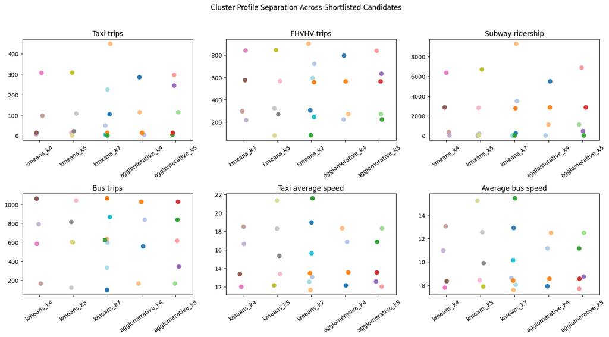

```python
# ---------------------------------------------------------------------
# Visualize cluster-profile separation across shortlisted candidates
# ---------------------------------------------------------------------

import matplotlib.pyplot as plt
import seaborn as sns

profile_plot_metrics = [
    "Taxi trips",
    "FHVHV trips",
    "Subway ridership",
    "Bus trips",
    "Taxi average speed",
    "Average bus speed",
]

profile_plot_df = readable_cluster_profile_long_df.loc[
    readable_cluster_profile_long_df["metric_label"].isin(profile_plot_metrics)
].copy()

solution_order = SHORTLISTED_SOLUTION_IDS
metric_order = profile_plot_metrics

# Give every solution-cluster pair a stable display id so its color stays
# consistent across all metric panels.
profile_plot_df["cluster_display_id"] = (
    profile_plot_df["solution_id"]
    + "_c"
    + profile_plot_df["cluster_label"].astype(str)
)

cluster_display_order = (
    profile_plot_df[["solution_id", "cluster_label", "cluster_display_id"]]
    .drop_duplicates()
    .sort_values(["solution_id", "cluster_label"])
)["cluster_display_id"].tolist()

palette = dict(
    zip(
        cluster_display_order,
        sns.color_palette("tab20", n_colors=len(cluster_display_order)),
    )
)

fig, axes = plt.subplots(2, 3, figsize=(15, 8))
axes = axes.flatten()

for ax, metric_label in zip(axes, metric_order):
    metric_df = profile_plot_df.loc[
        profile_plot_df["metric_label"] == metric_label
    ].copy()

    sns.stripplot(
        data=metric_df,
        x="solution_id",
        y="cluster_mean_value",
        hue="cluster_display_id",
        order=solution_order,
        hue_order=cluster_display_order,
        palette=palette,
        dodge=False,
        size=8,
        alpha=0.95,
        ax=ax,
    )

    ax.set_title(metric_label)
    ax.set_xlabel("")
    ax.set_ylabel("")
    ax.tick_params(axis="x", rotation=35)

    # Remove legends from every panel to keep the figure readable.
    legend = ax.get_legend()
    if legend is not None:
        legend.remove()

plt.suptitle("Cluster-Profile Separation Across Shortlisted Candidates", y=1.02)
plt.tight_layout()
plt.show()
```

Findings. The shortlisted candidates are all producing real separation on the core mobility measures, but they are doing it with different levels of sharpness. The two Agglomerative solutions and the lower-K K-Means solutions still show clear spreads between quieter, bus- or surface-heavy clusters and much busier, subway- and taxi-heavy clusters, which means they are carving out recognizable mobility regimes rather than collapsing into lookalike groups. kmeans_k7 stands out as the most aggressive separator, with especially wide spreads on Taxi trips, FHVHV trips, Subway ridership, Taxi average speed, and Average bus speed. So the main takeaway from this chart is that all five shortlisted candidates remain substantively alive, but the higher-resolution K-Means option is pulling clusters apart more strongly than the lower-K alternatives.

Summarize cluster-profile spread across shortlisted candidates. This final table compresses the profile-separation story into one simple measure per solution × metric: the spread between the highest and lowest cluster means. That gives us a compact way to compare how sharply each candidate differentiates the main mobility dimensions.

```python
# ---------------------------------------------------------------------
# Summarize cluster-profile spread across shortlisted candidates
# ---------------------------------------------------------------------

cluster_profile_spread_df = (
    readable_cluster_profile_long_df
    .groupby(
        ["solution_id", "cluster_method", "cluster_count", "metric_label"],
        as_index=False,
        dropna=False,
    )
    .agg(
        min_cluster_mean=("cluster_mean_value", "min"),
        max_cluster_mean=("cluster_mean_value", "max"),
    )
)

cluster_profile_spread_df["cluster_profile_spread"] = (
    cluster_profile_spread_df["max_cluster_mean"]
    - cluster_profile_spread_df["min_cluster_mean"]
).round(3)

display(cluster_profile_spread_df)
```

|  | solution_id | cluster_method | cluster_count | metric_label | min_cluster_mean | max_cluster_mean | cluster_profile_spread |
| --- | --- | --- | --- | --- | --- | --- | --- |
| 0 | agglomerative_k4 | agglomerative | 4 | Average bus speed | 7.902 | 12.472 | 4.570 |
| 1 | agglomerative_k4 | agglomerative | 4 | Bus trips | 163.286 | 1026.830 | 863.544 |
| 2 | agglomerative_k4 | agglomerative | 4 | FHVHV average duration | 997.484 | 1342.650 | 345.166 |
| 3 | agglomerative_k4 | agglomerative | 4 | FHVHV average speed | 15.494 | 18.953 | 3.459 |
| 4 | agglomerative_k4 | agglomerative | 4 | FHVHV trips | 221.924 | 793.166 | 571.242 |
| 5 | agglomerative_k4 | agglomerative | 4 | Subway ridership | 0.000 | 5492.702 | 5492.702 |
| 6 | agglomerative_k4 | agglomerative | 4 | Subway transfers | 0.000 | 223.029 | 223.029 |
| 7 | agglomerative_k4 | agglomerative | 4 | Taxi average duration | 1054.141 | 1976.785 | 922.644 |
| 8 | agglomerative_k4 | agglomerative | 4 | Taxi average speed | 12.150 | 18.315 | 6.165 |
| 9 | agglomerative_k4 | agglomerative | 4 | Taxi trips | 3.509 | 284.808 | 281.299 |
| 10 | agglomerative_k5 | agglomerative | 5 | Average bus speed | 7.675 | 12.472 | 4.797 |
| 11 | agglomerative_k5 | agglomerative | 5 | Bus trips | 163.286 | 1026.830 | 863.544 |
| 12 | agglomerative_k5 | agglomerative | 5 | FHVHV average duration | 997.484 | 1342.650 | 345.166 |
| 13 | agglomerative_k5 | agglomerative | 5 | FHVHV average speed | 15.346 | 18.953 | 3.607 |
| 14 | agglomerative_k5 | agglomerative | 5 | FHVHV trips | 221.924 | 837.634 | 615.710 |
| 15 | agglomerative_k5 | agglomerative | 5 | Subway ridership | 0.000 | 6882.120 | 6882.120 |
| 16 | agglomerative_k5 | agglomerative | 5 | Subway transfers | 0.000 | 223.029 | 223.029 |
| 17 | agglomerative_k5 | agglomerative | 5 | Taxi average duration | 964.632 | 1976.785 | 1012.153 |
| 18 | agglomerative_k5 | agglomerative | 5 | Taxi average speed | 12.030 | 18.315 | 6.285 |
| 19 | agglomerative_k5 | agglomerative | 5 | Taxi trips | 3.509 | 296.106 | 292.597 |
| 20 | kmeans_k4 | kmeans | 4 | Average bus speed | 7.776 | 13.029 | 5.253 |
| 21 | kmeans_k4 | kmeans | 4 | Bus trips | 163.117 | 1060.040 | 896.923 |
| 22 | kmeans_k4 | kmeans | 4 | FHVHV average duration | 1005.373 | 1377.416 | 372.043 |
| 23 | kmeans_k4 | kmeans | 4 | FHVHV average speed | 15.375 | 19.285 | 3.910 |
| 24 | kmeans_k4 | kmeans | 4 | FHVHV trips | 215.727 | 840.078 | 624.351 |
| 25 | kmeans_k4 | kmeans | 4 | Subway ridership | 0.000 | 6356.058 | 6356.058 |
| 26 | kmeans_k4 | kmeans | 4 | Subway transfers | 0.000 | 216.555 | 216.555 |
| 27 | kmeans_k4 | kmeans | 4 | Taxi average duration | 1065.997 | 1927.720 | 861.723 |
| 28 | kmeans_k4 | kmeans | 4 | Taxi average speed | 12.008 | 18.491 | 6.483 |
| 29 | kmeans_k4 | kmeans | 4 | Taxi trips | 5.566 | 305.917 | 300.351 |
| 30 | kmeans_k5 | kmeans | 5 | Average bus speed | 7.871 | 15.231 | 7.360 |
| 31 | kmeans_k5 | kmeans | 5 | Bus trips | 119.627 | 1040.857 | 921.230 |
| 32 | kmeans_k5 | kmeans | 5 | FHVHV average duration | 1004.251 | 1384.871 | 380.620 |
| 33 | kmeans_k5 | kmeans | 5 | FHVHV average speed | 15.436 | 21.284 | 5.848 |
| 34 | kmeans_k5 | kmeans | 5 | FHVHV trips | 78.601 | 844.929 | 766.328 |
| 35 | kmeans_k5 | kmeans | 5 | Subway ridership | 0.000 | 6704.111 | 6704.111 |
| 36 | kmeans_k5 | kmeans | 5 | Subway transfers | 0.000 | 211.637 | 211.637 |
| 37 | kmeans_k5 | kmeans | 5 | Taxi average duration | 1073.082 | 2188.835 | 1115.753 |
| 38 | kmeans_k5 | kmeans | 5 | Taxi average speed | 12.155 | 21.342 | 9.187 |
| 39 | kmeans_k5 | kmeans | 5 | Taxi trips | 0.126 | 307.258 | 307.132 |
| 40 | kmeans_k7 | kmeans | 7 | Average bus speed | 7.575 | 15.430 | 7.855 |
| 41 | kmeans_k7 | kmeans | 7 | Bus trips | 95.011 | 1063.849 | 968.838 |
| 42 | kmeans_k7 | kmeans | 7 | FHVHV average duration | 996.494 | 1412.884 | 416.390 |
| 43 | kmeans_k7 | kmeans | 7 | FHVHV average speed | 15.021 | 21.587 | 6.566 |
| 44 | kmeans_k7 | kmeans | 7 | FHVHV trips | 80.982 | 900.439 | 819.457 |
| 45 | kmeans_k7 | kmeans | 7 | Subway ridership | 0.000 | 9306.054 | 9306.054 |
| 46 | kmeans_k7 | kmeans | 7 | Subway transfers | 0.000 | 218.525 | 218.525 |
| 47 | kmeans_k7 | kmeans | 7 | Taxi average duration | 910.098 | 2213.873 | 1303.775 |
| 48 | kmeans_k7 | kmeans | 7 | Taxi average speed | 11.655 | 21.566 | 9.911 |
| 49 | kmeans_k7 | kmeans | 7 | Taxi trips | 0.088 | 448.526 | 448.438 |

Findings. The spread table sharpens the visual impression into something easier to compare. K-Means k = 7 produces the largest spreads on many metrics, including Subway ridership, Taxi trips, Taxi average duration, Taxi average speed, FHVHV trips, and Bus trips, which means it is the most aggressive at pulling clusters apart on the main mobility dimensions. kmeans_k5 is also quite strong, while kmeans_k4, agglomerative_k4, and agglomerative_k5 still show substantial separation but in a more restrained way. So the tradeoff is getting clearer: the higher-resolution K-Means candidates are creating the sharpest behavioral differences, but the lower-K options may still be easier to interpret and defend.

### Section summary

This section took us from technical screening into actual cluster interpretation. We narrowed the candidate field to five plausible solutions, rebuilt their cluster profiles in real units, and checked whether those candidates were separating meaningful mobility regimes rather than just producing mathematically distinct groups. The main takeaway is that all five shortlisted solutions are still substantively alive: the lower-K options remain simpler and easier to defend, while kmeans_k7 creates the strongest profile separation and stays the most interesting higher-resolution contender. At this point, the shortlist still holds, but the final choice now depends less on technical screening and more on whether the pre/post transition behavior and spatial validation views in the next steps make that extra complexity worth it.

## 3.2.1.5 Measure pre/post cluster reassignment behavior

This section checks how much Taxi Zones actually change mobility neighborhood after congestion pricing under each shortlisted candidate solution. Since every Taxi Zone appears once in the pre period and once in the post period, we can line those rows up directly and ask whether a candidate produces almost no reassignment, too much scattered reassignment, or something in the middle that feels interpretable and useful.

### Build zone-level pre/post cluster transition table

The first step is to line up the pre and post cluster assignments for the same Taxi Zone inside each shortlisted candidate solution. That gives us one row per solution × taxi_zone_id, which becomes the backbone for the rest of the section.

```python
# ---------------------------------------------------------------------
# Build zone-level pre/post cluster transition table for shortlisted candidates
# ---------------------------------------------------------------------

shortlisted_transition_source_df = shortlisted_candidate_assignments_df.copy()

zone_lookup_df = (
    clustering_metadata_df[
        ["taxi_zone_id", "zone", "borough", "cbd_spatial_category"]
    ]
    .drop_duplicates(subset=["taxi_zone_id"])
    .reset_index(drop=True)
)

pre_cluster_df = (
    shortlisted_transition_source_df.loc[
        shortlisted_transition_source_df["pre_post_cp"] == "pre_cp",
        ["solution_id", "cluster_method", "cluster_count", "taxi_zone_id", "cluster_label"],
    ]
    .rename(columns={"cluster_label": "pre_cluster_label"})
)

post_cluster_df = (
    shortlisted_transition_source_df.loc[
        shortlisted_transition_source_df["pre_post_cp"] == "post_cp",
        ["solution_id", "cluster_method", "cluster_count", "taxi_zone_id", "cluster_label"],
    ]
    .rename(columns={"cluster_label": "post_cluster_label"})
)

zone_cluster_transition_df = (
    pre_cluster_df
    .merge(
        post_cluster_df,
        on=["solution_id", "cluster_method", "cluster_count", "taxi_zone_id"],
        how="inner",
    )
    .merge(
        zone_lookup_df,
        on="taxi_zone_id",
        how="left",
    )
    .sort_values(["solution_id", "taxi_zone_id"])
    .reset_index(drop=True)
)

zone_cluster_transition_df["cluster_changed_flag"] = (
    zone_cluster_transition_df["pre_cluster_label"]
    != zone_cluster_transition_df["post_cluster_label"]
)

print(
    f"Built zone-level transition rows: {len(zone_cluster_transition_df):,}",
    flush=True,
)
```

```
Built zone-level transition rows: 1,315
```

Preview zone-level pre/post transitions. This preview is just here to make the transition table visible before we summarize it. The goal is not to read every row. It is to confirm that the structure makes sense and that we are really comparing pre vs post cluster labels for the same Taxi Zone.

```python
# ---------------------------------------------------------------------
# Preview zone-level pre/post transitions
# ---------------------------------------------------------------------

transition_preview_df = (
    zone_cluster_transition_df
    .sort_values(
        ["solution_id", "cluster_changed_flag", "taxi_zone_id"],
        ascending=[True, False, True],
    )
    .reset_index(drop=True)
)

display(
    transition_preview_df[
        [
            "solution_id",
            "taxi_zone_id",
            "zone",
            "borough",
            "cbd_spatial_category",
            "pre_cluster_label",
            "post_cluster_label",
            "cluster_changed_flag",
        ]
    ].head(20)
)
```

|  | solution_id | taxi_zone_id | zone | borough | cbd_spatial_category | pre_cluster_label | post_cluster_label | cluster_changed_flag |
| --- | --- | --- | --- | --- | --- | --- | --- | --- |
| 0 | agglomerative_k4 | 1 | Newark Airport | EWR | gateway_to_cbd | 1 | 3 | True |
| 1 | agglomerative_k4 | 54 | Columbia Street | Brooklyn | non_cbd | 0 | 3 | True |
| 2 | agglomerative_k4 | 2 | Jamaica Bay | Queens | non_cbd | 3 | 3 | False |
| 3 | agglomerative_k4 | 3 | Allerton/Pelham Gardens | Bronx | non_cbd | 2 | 2 | False |
| 4 | agglomerative_k4 | 4 | Alphabet City | Manhattan | cbd | 0 | 0 | False |
| 5 | agglomerative_k4 | 5 | Arden Heights | Staten Island | non_cbd | 1 | 1 | False |
| 6 | agglomerative_k4 | 6 | Arrochar/Fort Wadsworth | Staten Island | non_cbd | 1 | 1 | False |
| 7 | agglomerative_k4 | 7 | Astoria | Queens | non_cbd | 2 | 2 | False |
| 8 | agglomerative_k4 | 8 | Astoria Park | Queens | non_cbd | 3 | 3 | False |
| 9 | agglomerative_k4 | 9 | Auburndale | Queens | non_cbd | 1 | 1 | False |
| 10 | agglomerative_k4 | 10 | Baisley Park | Queens | non_cbd | 1 | 1 | False |
| 11 | agglomerative_k4 | 11 | Bath Beach | Brooklyn | non_cbd | 1 | 1 | False |
| 12 | agglomerative_k4 | 12 | Battery Park | Manhattan | cbd | 3 | 3 | False |
| 13 | agglomerative_k4 | 13 | Battery Park City | Manhattan | cbd | 0 | 0 | False |
| 14 | agglomerative_k4 | 14 | Bay Ridge | Brooklyn | non_cbd | 2 | 2 | False |
| 15 | agglomerative_k4 | 15 | Bay Terrace/Fort Totten | Queens | non_cbd | 1 | 1 | False |
| 16 | agglomerative_k4 | 16 | Bayside | Queens | non_cbd | 1 | 1 | False |
| 17 | agglomerative_k4 | 17 | Bedford | Brooklyn | non_cbd | 0 | 0 | False |
| 18 | agglomerative_k4 | 18 | Bedford Park | Bronx | non_cbd | 2 | 2 | False |
| 19 | agglomerative_k4 | 19 | Bellerose | Queens | non_cbd | 1 | 1 | False |

Findings. Even this small preview shows that pre/post cluster reassignment is relatively rare for the shortlisted candidates. Under agglomerative_k4, only Newark Airport and Columbia Street change clusters in the visible slice, while the rest of the previewed zones stay put. That already suggests the low-K Agglomerative solutions are producing a very stable mobility-neighborhood structure, with only a small number of zones shifting identity after congestion pricing.

### Summarize transition rates by candidate

Now that we have the row-level transition table, we can measure how much reassignment each shortlisted candidate is producing and how concentrated those transitions are. This is where we start to distinguish between candidates that are too rigid, too chaotic, or usefully in between.

Summarize overall reassignment rates by candidate solution. This first summary asks the most basic question: how many Taxi Zones stay in the same cluster, and how many move? That gives us the overall reassignment rate for each candidate.

```python
# ---------------------------------------------------------------------
# Summarize overall reassignment rates by candidate solution
# ---------------------------------------------------------------------

candidate_reassignment_summary_df = (
    zone_cluster_transition_df
    .groupby(
        ["solution_id", "cluster_method", "cluster_count"],
        as_index=False,
        dropna=False,
    )
    .agg(
        taxi_zone_count=("taxi_zone_id", "count"),
        changed_zone_count=("cluster_changed_flag", "sum"),
    )
)

candidate_reassignment_summary_df["changed_zone_share"] = (
    candidate_reassignment_summary_df["changed_zone_count"]
    / candidate_reassignment_summary_df["taxi_zone_count"]
).round(3)

candidate_reassignment_summary_df["stable_zone_count"] = (
    candidate_reassignment_summary_df["taxi_zone_count"]
    - candidate_reassignment_summary_df["changed_zone_count"]
)

candidate_reassignment_summary_df["stable_zone_share"] = (
    candidate_reassignment_summary_df["stable_zone_count"]
    / candidate_reassignment_summary_df["taxi_zone_count"]
).round(3)

display(candidate_reassignment_summary_df)
```

|  | solution_id | cluster_method | cluster_count | taxi_zone_count | changed_zone_count | changed_zone_share | stable_zone_count | stable_zone_share |
| --- | --- | --- | --- | --- | --- | --- | --- | --- |
| 0 | agglomerative_k4 | agglomerative | 4 | 263 | 2 | 0.008 | 261 | 0.992 |
| 1 | agglomerative_k5 | agglomerative | 5 | 263 | 3 | 0.011 | 260 | 0.989 |
| 2 | kmeans_k4 | kmeans | 4 | 263 | 6 | 0.023 | 257 | 0.977 |
| 3 | kmeans_k5 | kmeans | 5 | 263 | 6 | 0.023 | 257 | 0.977 |
| 4 | kmeans_k7 | kmeans | 7 | 263 | 9 | 0.034 | 254 | 0.966 |

Findings. Reassignment rates are low across the whole shortlist, but they are not identical. The two Agglomerative solutions are the most stable by far, with only 2 and 3 zones changing cluster, or about 0.8% to 1.1% of all Taxi Zones. kmeans_k4 and kmeans_k5 allow slightly more movement at 2.3%, while kmeans_k7 produces the most reassignment at 3.4%. So the main pattern is that all five candidates are fairly stable, but the higher-resolution K-Means solution is the one that gives the pre/post story the most room to breathe.

Summarize transition-path concentration by candidate solution. Overall reassignment rate is only part of the story. This block asks how concentrated the transition structure is. If most changes flow through just one or two dominant paths, that is very different from a candidate where the changes are scattered across a dozen tiny paths.

```python
# ---------------------------------------------------------------------
# Summarize transition-path concentration by candidate solution
# ---------------------------------------------------------------------

transition_path_counts_df = (
    zone_cluster_transition_df
    .groupby(
        [
            "solution_id",
            "cluster_method",
            "cluster_count",
            "pre_cluster_label",
            "post_cluster_label",
        ],
        as_index=False,
        dropna=False,
    )
    .agg(
        zone_count=("taxi_zone_id", "count"),
    )
)

transition_path_counts_df["transition_path_label"] = (
    "pre "
    + transition_path_counts_df["pre_cluster_label"].astype(str)
    + " → post "
    + transition_path_counts_df["post_cluster_label"].astype(str)
)

candidate_transition_path_summary_df = (
    transition_path_counts_df
    .sort_values(
        ["solution_id", "zone_count"],
        ascending=[True, False],
    )
    .groupby(
        ["solution_id", "cluster_method", "cluster_count"],
        as_index=False,
        dropna=False,
    )
    .agg(
        distinct_transition_path_count=("transition_path_label", "nunique"),
        largest_transition_path_count=("zone_count", "max"),
        top_3_transition_path_count=("zone_count", lambda s: s.head(3).sum()),
    )
)

candidate_transition_path_summary_df = candidate_transition_path_summary_df.merge(
    candidate_reassignment_summary_df[
        ["solution_id", "taxi_zone_count"]
    ],
    on="solution_id",
    how="left",
)

candidate_transition_path_summary_df["largest_transition_path_share"] = (
    candidate_transition_path_summary_df["largest_transition_path_count"]
    / candidate_transition_path_summary_df["taxi_zone_count"]
).round(3)

candidate_transition_path_summary_df["top_3_transition_path_share"] = (
    candidate_transition_path_summary_df["top_3_transition_path_count"]
    / candidate_transition_path_summary_df["taxi_zone_count"]
).round(3)

display(
    candidate_transition_path_summary_df[
        [
            "solution_id",
            "cluster_method",
            "cluster_count",
            "distinct_transition_path_count",
            "largest_transition_path_count",
            "largest_transition_path_share",
            "top_3_transition_path_count",
            "top_3_transition_path_share",
        ]
    ]
)
```

|  | solution_id | cluster_method | cluster_count | distinct_transition_path_count | largest_transition_path_count | largest_transition_path_share | top_3_transition_path_count | top_3_transition_path_share |
| --- | --- | --- | --- | --- | --- | --- | --- | --- |
| 0 | agglomerative_k4 | agglomerative | 4 | 6 | 96 | 0.365 | 239 | 0.909 |
| 1 | agglomerative_k5 | agglomerative | 5 | 8 | 96 | 0.365 | 224 | 0.852 |
| 2 | kmeans_k4 | kmeans | 4 | 10 | 90 | 0.342 | 234 | 0.890 |
| 3 | kmeans_k5 | kmeans | 5 | 10 | 93 | 0.354 | 221 | 0.840 |
| 4 | kmeans_k7 | kmeans | 7 | 13 | 86 | 0.327 | 182 | 0.692 |

Findings. The transition-path concentration view helps separate “stable” from “too rigid.” For both Agglomerative candidates, the single largest transition path captures 36.5% of all zones, and the top three paths capture 85% to 91%, which means most of the city is staying concentrated in a very small number of dominant pre/post patterns. The K-Means candidates are still structured, but less locked down: kmeans_k4 and kmeans_k5 spread movement across 10 distinct paths, and kmeans_k7 opens up to 13 paths while lowering the top-three concentration to 69.2%. That makes kmeans_k7 the least rigid candidate in the shortlist.

Preview the strongest transition pathways. This block surfaces the biggest actual transition paths for each shortlisted candidate. It gives us a more concrete feel for whether a solution is producing a few interpretable reassignment stories or just scattering zones in all directions.

```python
# ---------------------------------------------------------------------
# Preview the strongest transition pathways
# ---------------------------------------------------------------------

top_transition_paths_df = (
    transition_path_counts_df
    .sort_values(
        ["solution_id", "zone_count"],
        ascending=[True, False],
    )
    .groupby("solution_id", group_keys=False)
    .head(8)
    .reset_index(drop=True)
)

display(
    top_transition_paths_df[
        [
            "solution_id",
            "transition_path_label",
            "zone_count",
        ]
    ]
)
```

|  | solution_id | transition_path_label | zone_count |
| --- | --- | --- | --- |
| 0 | agglomerative_k4 | pre 2 → post 2 | 96 |
| 1 | agglomerative_k4 | pre 1 → post 1 | 74 |
| 2 | agglomerative_k4 | pre 0 → post 0 | 69 |
| 3 | agglomerative_k4 | pre 3 → post 3 | 22 |
| 4 | agglomerative_k4 | pre 0 → post 3 | 1 |
| 5 | agglomerative_k4 | pre 1 → post 3 | 1 |
| 6 | agglomerative_k5 | pre 2 → post 2 | 96 |
| 7 | agglomerative_k5 | pre 0 → post 0 | 74 |
| 8 | agglomerative_k5 | pre 3 → post 3 | 54 |
| 9 | agglomerative_k5 | pre 1 → post 1 | 22 |
| 10 | agglomerative_k5 | pre 4 → post 4 | 14 |
| 11 | agglomerative_k5 | pre 0 → post 1 | 1 |
| 12 | agglomerative_k5 | pre 3 → post 4 | 1 |
| 13 | agglomerative_k5 | pre 4 → post 1 | 1 |
| 14 | kmeans_k4 | pre 1 → post 1 | 90 |
| 15 | kmeans_k4 | pre 0 → post 0 | 81 |
| 16 | kmeans_k4 | pre 3 → post 3 | 63 |
| 17 | kmeans_k4 | pre 2 → post 2 | 23 |
| 18 | kmeans_k4 | pre 0 → post 2 | 1 |
| 19 | kmeans_k4 | pre 1 → post 3 | 1 |
| 20 | kmeans_k4 | pre 2 → post 0 | 1 |
| 21 | kmeans_k4 | pre 3 → post 0 | 1 |
| 22 | kmeans_k5 | pre 0 → post 0 | 93 |
| 23 | kmeans_k5 | pre 1 → post 1 | 68 |
| 24 | kmeans_k5 | pre 3 → post 3 | 60 |
| 25 | kmeans_k5 | pre 2 → post 2 | 20 |
| 26 | kmeans_k5 | pre 4 → post 4 | 16 |
| 27 | kmeans_k5 | pre 4 → post 2 | 2 |
| 28 | kmeans_k5 | pre 0 → post 2 | 1 |
| 29 | kmeans_k5 | pre 3 → post 0 | 1 |
| 30 | kmeans_k7 | pre 4 → post 4 | 86 |
| 31 | kmeans_k7 | pre 0 → post 0 | 62 |
| 32 | kmeans_k7 | pre 5 → post 5 | 34 |
| 33 | kmeans_k7 | pre 3 → post 3 | 27 |
| 34 | kmeans_k7 | pre 2 → post 2 | 17 |
| 35 | kmeans_k7 | pre 6 → post 6 | 16 |
| 36 | kmeans_k7 | pre 1 → post 1 | 12 |
| 37 | kmeans_k7 | pre 4 → post 3 | 2 |

Findings. The strongest transition pathways confirm that stability dominates the shortlist. For every candidate, the biggest flows are unchanged paths like pre 2 → post 2, pre 1 → post 1, or pre 0 → post 0, while actual reassignment paths are tiny, often just one or two zones. The difference is that kmeans_k7 spreads the city across more stable cluster pathways and introduces a slightly richer set of low-volume changes, whereas the two Agglomerative solutions are more tightly concentrated in a handful of dominant unchanged paths.

### Review zone transition by geography

This subsection adds the missing spatial view of reassignment. We already know how much cluster change each candidate produces; now we want to see where those shifts are happening. The goal is to tell the difference between candidates whose cluster changes fall in a small, believable set of zones and candidates whose changes look scattered or arbitrary.

Map changed zones for K-Means candidates. Render the K-Means candidates separately so the transition maps stay readable and within Deepnote’s output limits. Each panel shows only whether a Taxi Zone changed cluster from pre to post.

```python
# ---------------------------------------------------------------------
# Map the zones that changed cluster for K-Means candidates
# ---------------------------------------------------------------------

taxi_zone_map_df = pd.read_parquet(TAXI_ZONE_SPATIAL_CONTEXT_PATH)

taxi_zone_map_df = taxi_zone_map_df.loc[
    taxi_zone_map_df["geometry"].notna()
].copy()

taxi_zone_map_df["geometry"] = taxi_zone_map_df["geometry"].apply(
    lambda geom: wkb.loads(geom) if isinstance(geom, (bytes, bytearray, memoryview)) else geom
)

taxi_zone_plot_gdf = gpd.GeoDataFrame(
    taxi_zone_map_df,
    geometry="geometry",
    crs="EPSG:4326",
)

taxi_zone_plot_gdf = (
    taxi_zone_plot_gdf[
        ["location_id", "zone", "borough", "geometry"]
    ]
    .drop_duplicates(subset=["location_id"])
    .copy()
)

taxi_zone_plot_gdf["taxi_zone_id"] = taxi_zone_plot_gdf["location_id"].astype(int).astype(str)
taxi_zone_geojson = json.loads(taxi_zone_plot_gdf.to_json())

taxi_zone_projected_gdf = taxi_zone_plot_gdf.to_crs("EPSG:2263")
taxi_zone_centroids_4326 = gpd.GeoSeries(
    taxi_zone_projected_gdf.geometry.centroid,
    crs="EPSG:2263",
).to_crs("EPSG:4326")

map_center = {
    "lat": float(taxi_zone_centroids_4326.y.mean()),
    "lon": float(taxi_zone_centroids_4326.x.mean()),
}
map_zoom = 8.75

candidate_transition_map_df = zone_cluster_transition_df.copy()
candidate_transition_map_df["taxi_zone_id"] = (
    candidate_transition_map_df["taxi_zone_id"].astype(int).astype(str)
)
candidate_transition_map_df["change_flag_label"] = np.where(
    candidate_transition_map_df["cluster_changed_flag"],
    "Changed cluster",
    "No change",
)

kmeans_solution_order = (
    candidate_reassignment_summary_df.loc[
        candidate_reassignment_summary_df["cluster_method"].eq("kmeans"),
        ["solution_id", "cluster_count"]
    ]
    .drop_duplicates()
    .sort_values(["cluster_count", "solution_id"])
    ["solution_id"]
    .tolist()
)

transition_map_plot_df = taxi_zone_plot_gdf[
    ["taxi_zone_id", "zone", "borough"]
].merge(
    candidate_transition_map_df,
    on=["taxi_zone_id", "zone", "borough"],
    how="inner",
    validate="one_to_many",
)

transition_change_colorscale = [
    [0.00, "#EDF6F9"],
    [0.49, "#EDF6F9"],
    [0.50, "#E29578"],
    [1.00, "#E29578"],
]

n_candidates = len(kmeans_solution_order)
n_cols = 2
n_rows = math.ceil(n_candidates / n_cols)

subplot_titles = kmeans_solution_order.copy()
if len(subplot_titles) < (n_rows * n_cols):
    subplot_titles.extend([""] * ((n_rows * n_cols) - len(subplot_titles)))

fig = make_subplots(
    rows=n_rows,
    cols=n_cols,
    specs=[[{"type": "map"} for _ in range(n_cols)] for _ in range(n_rows)],
    subplot_titles=subplot_titles,
    horizontal_spacing=0.03,
    vertical_spacing=0.06,
)

for idx, solution_id in enumerate(kmeans_solution_order):
    row_idx = (idx // n_cols) + 1
    col_idx = (idx % n_cols) + 1

    plot_df = (
        transition_map_plot_df.loc[
            transition_map_plot_df["solution_id"].eq(solution_id)
        ]
        .copy()
        .reset_index(drop=True)
    )

    plot_df["change_flag_numeric"] = plot_df["cluster_changed_flag"].astype(int)

    customdata = np.column_stack(
        [
            plot_df["zone"].astype(str),
            plot_df["borough"].astype(str),
            plot_df["cbd_spatial_category"].astype(str),
            plot_df["pre_cluster_label"].astype(str),
            plot_df["post_cluster_label"].astype(str),
            plot_df["change_flag_label"].astype(str),
        ]
    )

    fig.add_trace(
        go.Choroplethmap(
            geojson=taxi_zone_geojson,
            featureidkey="properties.taxi_zone_id",
            locations=plot_df["taxi_zone_id"],
            z=plot_df["change_flag_numeric"],
            zmin=0,
            zmax=1,
            colorscale=transition_change_colorscale,
            marker_opacity=0.78,
            marker_line_width=0.35,
            marker_line_color="rgba(11, 78, 74, 0.35)",
            customdata=customdata,
            hovertemplate=(
                "<b>%{customdata[0]}</b><br>"
                "%{customdata[1]}<br>"
                "Policy geography: %{customdata[2]}<br>"
                "Pre cluster: %{customdata[3]}<br>"
                "Post cluster: %{customdata[4]}<br>"
                "Transition: %{customdata[5]}<extra></extra>"
            ),
            showscale=(idx == 0),
            colorbar=(
                dict(
                    title="Cluster<br>change",
                    tickvals=[0, 1],
                    ticktext=["No change", "Changed"],
                    len=0.45,
                    x=1.02,
                )
                if idx == 0
                else None
            ),
        ),
        row=row_idx,
        col=col_idx,
    )

layout_updates = dict(
    title="Where Taxi Zones Change Cluster Across K-Means Candidates",
    width=980,
    height=340 * n_rows,
    margin=dict(l=20, r=90, t=90, b=20),
)

for map_idx in range(1, (n_rows * n_cols) + 1):
    map_key = "map" if map_idx == 1 else f"map{map_idx}"

    layout_updates[map_key] = dict(
        style="carto-positron",
        center=map_center,
        zoom=map_zoom,
    )

fig.update_layout(**layout_updates)
fig.show()
```

[interactive chart not shown]

Findings. The K-Means candidates all keep most Taxi Zones stable, but they differ in how broadly they allow mobility identity to shift. kmeans_k4 changes only a small handful of zones, with the moved areas scattered across EWR, a few Manhattan-core locations, and isolated outer-borough pockets. kmeans_k5 keeps that same general structure but adds a much more visible concentration of changed zones in southeastern Queens, making the reassignment pattern feel more geographically legible. kmeans_k7 goes further: it still preserves broad stability, but the changed zones spread across more of the core and outer-borough edge cases, especially in lower Manhattan / Brooklyn-adjacent areas and southeastern Queens. So across the K-Means candidates, the progression is pretty clear: k4 is the most conservative, k5 adds a focused second pocket of change, and k7 produces the richest but also broadest reassignment geography.

Map changed zones for Agglomerative candidates. This map does the same thing for the Agglomerative candidates. Keeping the method families separate makes it easier to compare their reassignment behavior without clutter.

```python
# ---------------------------------------------------------------------
# Map the zones that changed cluster for Agglomerative candidates
# ---------------------------------------------------------------------

agglomerative_solution_order = (
    candidate_reassignment_summary_df.loc[
        candidate_reassignment_summary_df["cluster_method"].eq("agglomerative"),
        ["solution_id", "cluster_count"]
    ]
    .drop_duplicates()
    .sort_values(["cluster_count", "solution_id"])
    ["solution_id"]
    .tolist()
)

n_candidates = len(agglomerative_solution_order)
n_cols = 2
n_rows = math.ceil(n_candidates / n_cols)

subplot_titles = agglomerative_solution_order.copy()
if len(subplot_titles) < (n_rows * n_cols):
    subplot_titles.extend([""] * ((n_rows * n_cols) - len(subplot_titles)))

fig = make_subplots(
    rows=n_rows,
    cols=n_cols,
    specs=[[{"type": "map"} for _ in range(n_cols)] for _ in range(n_rows)],
    subplot_titles=subplot_titles,
    horizontal_spacing=0.03,
    vertical_spacing=0.06,
)

for idx, solution_id in enumerate(agglomerative_solution_order):
    row_idx = (idx // n_cols) + 1
    col_idx = (idx % n_cols) + 1

    plot_df = (
        transition_map_plot_df.loc[
            transition_map_plot_df["solution_id"].eq(solution_id)
        ]
        .copy()
        .reset_index(drop=True)
    )

    plot_df["change_flag_numeric"] = plot_df["cluster_changed_flag"].astype(int)

    customdata = np.column_stack(
        [
            plot_df["zone"].astype(str),
            plot_df["borough"].astype(str),
            plot_df["cbd_spatial_category"].astype(str),
            plot_df["pre_cluster_label"].astype(str),
            plot_df["post_cluster_label"].astype(str),
            plot_df["change_flag_label"].astype(str),
        ]
    )

    fig.add_trace(
        go.Choroplethmap(
            geojson=taxi_zone_geojson,
            featureidkey="properties.taxi_zone_id",
            locations=plot_df["taxi_zone_id"],
            z=plot_df["change_flag_numeric"],
            zmin=0,
            zmax=1,
            colorscale=transition_change_colorscale,
            marker_opacity=0.78,
            marker_line_width=0.35,
            marker_line_color="rgba(11, 78, 74, 0.35)",
            customdata=customdata,
            hovertemplate=(
                "<b>%{customdata[0]}</b><br>"
                "%{customdata[1]}<br>"
                "Policy geography: %{customdata[2]}<br>"
                "Pre cluster: %{customdata[3]}<br>"
                "Post cluster: %{customdata[4]}<br>"
                "Transition: %{customdata[5]}<extra></extra>"
            ),
            showscale=(idx == 0),
            colorbar=(
                dict(
                    title="Cluster<br>change",
                    tickvals=[0, 1],
                    ticktext=["No change", "Changed"],
                    len=0.45,
                    x=1.02,
                )
                if idx == 0
                else None
            ),
        ),
        row=row_idx,
        col=col_idx,
    )

layout_updates = dict(
    title="Where Taxi Zones Change Cluster Across Agglomerative Candidates",
    width=980,
    height=340 * n_rows,
    margin=dict(l=20, r=90, t=90, b=20),
)

for map_idx in range(1, (n_rows * n_cols) + 1):
    map_key = "map" if map_idx == 1 else f"map{map_idx}"
    layout_updates[map_key] = dict(
        style="carto-positron",
        center=map_center,
        zoom=map_zoom,
    )

fig.update_layout(**layout_updates)
fig.show()
```

[interactive chart not shown]

Findings. The Agglomerative candidates are much more rigid. agglomerative_k4 changes only two isolated zones, one around EWR and one in Brooklyn, and agglomerative_k5 adds just one more small Manhattan-core change. The overall impression is that Agglomerative produces almost no mobility-neighborhood reassignment at all, even after congestion pricing. That makes the pattern easy to read, but also arguably too static to capture meaningful pre/post shifts in mobility identity.

Summarize changed zones by geography. Let's make the transition pattern easier to interpret than a map alone. We want to know whether the changed zones cluster in Manhattan/CBD-oriented areas, gateway areas, or outer-borough neighborhoods, and whether those patterns differ across the candidate solutions.

```python
# ---------------------------------------------------------------------
# Summarize changed zones by borough and policy geography
# ---------------------------------------------------------------------

changed_zone_geography_summary_df = (
    zone_cluster_transition_df.loc[
        zone_cluster_transition_df["cluster_changed_flag"].eq(True)
    ]
    .groupby(
        ["solution_id", "cluster_method", "cluster_count", "borough", "cbd_spatial_category"],
        dropna=False,
        observed=True,
    )
    .agg(
        changed_zone_count=("taxi_zone_id", "nunique"),
    )
    .reset_index()
)

candidate_changed_totals_df = (
    zone_cluster_transition_df.loc[
        zone_cluster_transition_df["cluster_changed_flag"].eq(True)
    ]
    .groupby(
        ["solution_id", "cluster_method", "cluster_count"],
        observed=True,
    )
    .agg(total_changed_zones=("taxi_zone_id", "nunique"))
    .reset_index()
)

changed_zone_geography_summary_df = changed_zone_geography_summary_df.merge(
    candidate_changed_totals_df,
    on=["solution_id", "cluster_method", "cluster_count"],
    how="left",
    validate="many_to_one",
)

changed_zone_geography_summary_df["changed_zone_share_within_solution"] = (
    changed_zone_geography_summary_df["changed_zone_count"]
    / changed_zone_geography_summary_df["total_changed_zones"]
)

changed_zone_geography_summary_df = changed_zone_geography_summary_df.sort_values(
    [
        "cluster_method",
        "cluster_count",
        "solution_id",
        "changed_zone_count",
        "borough",
        "cbd_spatial_category",
    ],
    ascending=[True, True, True, False, True, True],
).reset_index(drop=True)

display(
    changed_zone_geography_summary_df.style.format(
        {"changed_zone_share_within_solution": "{:.3f}"}
    )
)
```

|  | solution_id | cluster_method | cluster_count | borough | cbd_spatial_category | changed_zone_count | total_changed_zones | changed_zone_share_within_solution |
| --- | --- | --- | --- | --- | --- | --- | --- | --- |
| 0 | agglomerative_k4 | agglomerative | 4 | Brooklyn | non_cbd | 1 | 2 | 0.500 |
| 1 | agglomerative_k4 | agglomerative | 4 | EWR | gateway_to_cbd | 1 | 2 | 0.500 |
| 2 | agglomerative_k5 | agglomerative | 5 | Brooklyn | non_cbd | 1 | 3 | 0.333 |
| 3 | agglomerative_k5 | agglomerative | 5 | EWR | gateway_to_cbd | 1 | 3 | 0.333 |
| 4 | agglomerative_k5 | agglomerative | 5 | Manhattan | cbd | 1 | 3 | 0.333 |
| 5 | kmeans_k4 | kmeans | 4 | Manhattan | cbd | 2 | 6 | 0.333 |
| 6 | kmeans_k4 | kmeans | 4 | Bronx | non_cbd | 1 | 6 | 0.167 |
| 7 | kmeans_k4 | kmeans | 4 | Brooklyn | non_cbd | 1 | 6 | 0.167 |
| 8 | kmeans_k4 | kmeans | 4 | EWR | gateway_to_cbd | 1 | 6 | 0.167 |
| 9 | kmeans_k4 | kmeans | 4 | Queens | gateway_to_cbd | 1 | 6 | 0.167 |
| 10 | kmeans_k5 | kmeans | 5 | Manhattan | cbd | 2 | 6 | 0.333 |
| 11 | kmeans_k5 | kmeans | 5 | Queens | non_cbd | 2 | 6 | 0.333 |
| 12 | kmeans_k5 | kmeans | 5 | EWR | gateway_to_cbd | 1 | 6 | 0.167 |
| 13 | kmeans_k5 | kmeans | 5 | Queens | gateway_to_cbd | 1 | 6 | 0.167 |
| 14 | kmeans_k7 | kmeans | 7 | Brooklyn | non_cbd | 3 | 9 | 0.333 |
| 15 | kmeans_k7 | kmeans | 7 | Manhattan | cbd | 2 | 9 | 0.222 |
| 16 | kmeans_k7 | kmeans | 7 | Queens | non_cbd | 2 | 9 | 0.222 |
| 17 | kmeans_k7 | kmeans | 7 | EWR | gateway_to_cbd | 1 | 9 | 0.111 |
| 18 | kmeans_k7 | kmeans | 7 | Manhattan | non_cbd | 1 | 9 | 0.111 |

Findings. The changed zones stay fairly concentrated in every candidate, but the pattern gets more citywide as we move from Agglomerative to K-Means and then from lower-k to higher-k. agglomerative_k4 changes only two zones, split between Brooklyn non_cbd and the EWR gateway. agglomerative_k5 adds just one Manhattan CBD zone, so it is still extremely rigid. kmeans_k4 is broader but still compact, with one-third of its changed zones in Manhattan CBD and the rest spread one each across the Bronx, Brooklyn, EWR gateway, and Queens gateway. kmeans_k5 keeps Manhattan CBD important but shifts more of the reassignment into Queens, including both non_cbd and gateway zones. kmeans_k7 is the broadest of the finalists, with its changed zones spread across Brooklyn, Manhattan, Queens, and EWR, and with Brooklyn non_cbd emerging as the single biggest changed slice. Overall, this makes the K-Means candidates look more behaviorally flexible, while the Agglomerative candidates still read as very conservative.

### Review candidate solutions through a transition lens

This final subsection brings the transition behavior together into one review view. By this point, we should be able to tell which candidates are too stable to be interesting, which ones are too jumpy to trust, and which ones are producing a pre/post reassignment story that might actually be useful.

Assemble transition screening summary. This table combines the overall reassignment rates and the transition-path concentration measures into one compact summary. This is the main table we should use to judge the shortlisted candidates through the transition lens.

```python
# ---------------------------------------------------------------------
# Assemble transition screening summary
# ---------------------------------------------------------------------

candidate_transition_screening_df = (
    candidate_reassignment_summary_df
    .merge(
        candidate_transition_path_summary_df[
            [
                "solution_id",
                "cluster_method",
                "cluster_count",
                "distinct_transition_path_count",
                "largest_transition_path_share",
                "top_3_transition_path_share",
            ]
        ],
        on=["solution_id", "cluster_method", "cluster_count"],
        how="inner",
    )
    .sort_values(["cluster_method", "cluster_count"])
    .reset_index(drop=True)
)

display(candidate_transition_screening_df)
```

|  | solution_id | cluster_method | cluster_count | taxi_zone_count | changed_zone_count | changed_zone_share | stable_zone_count | stable_zone_share | distinct_transition_path_count | largest_transition_path_share | top_3_transition_path_share |
| --- | --- | --- | --- | --- | --- | --- | --- | --- | --- | --- | --- |
| 0 | agglomerative_k4 | agglomerative | 4 | 263 | 2 | 0.008 | 261 | 0.992 | 6 | 0.365 | 0.909 |
| 1 | agglomerative_k5 | agglomerative | 5 | 263 | 3 | 0.011 | 260 | 0.989 | 8 | 0.365 | 0.852 |
| 2 | kmeans_k4 | kmeans | 4 | 263 | 6 | 0.023 | 257 | 0.977 | 10 | 0.342 | 0.890 |
| 3 | kmeans_k5 | kmeans | 5 | 263 | 6 | 0.023 | 257 | 0.977 | 10 | 0.354 | 0.840 |
| 4 | kmeans_k7 | kmeans | 7 | 263 | 9 | 0.034 | 254 | 0.966 | 13 | 0.327 | 0.692 |

Findings. The transition screening summary makes the tradeoff clear. agglomerative_k4 and agglomerative_k5 are the most stable candidates, but they may also be too rigid, because almost no zones move and the city remains highly concentrated in a few dominant transition paths. kmeans_k4 and kmeans_k5 open up a little more movement without becoming noisy. kmeans_k7 is the most dynamic candidate, with the highest reassignment rate, the most distinct transition paths, and the lowest top-three transition-path concentration. So if the goal is to preserve some meaningful pre/post mobility-identity shift rather than locking almost every zone in place, kmeans_k7 looks the most interesting from the transition lens.

Visualize transition behavior across shortlisted candidates. This chart puts the main transition tradeoffs in one place. Higher reassignment share means more Taxi Zones change mobility neighborhood, while higher largest-path share means the movement is more concentrated in one dominant pathway. That gives us a simple way to see whether a candidate looks rigid, chaotic, or reasonably structured.

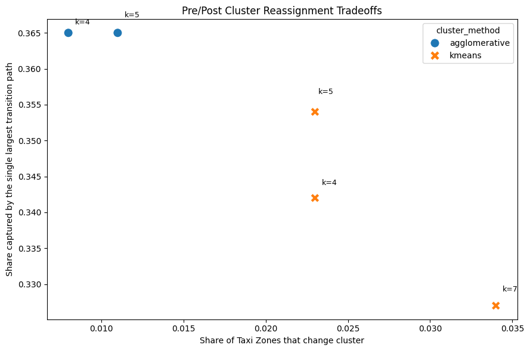

```python
# ---------------------------------------------------------------------
# Visualize transition behavior across shortlisted candidates
# ---------------------------------------------------------------------

plot_transition_df = candidate_transition_screening_df.copy()

plt.figure(figsize=(9, 6))

sns.scatterplot(
    data=plot_transition_df,
    x="changed_zone_share",
    y="largest_transition_path_share",
    hue="cluster_method",
    style="cluster_method",
    s=120,
)

# Use solution-specific offsets so nearby labels do not stack awkwardly.
label_offsets = {
    "agglomerative_k4": (0.0004, 0.0012),
    "agglomerative_k5": (0.0004, 0.0022),
    "kmeans_k4": (0.0004, 0.0018),
    "kmeans_k5": (0.0002, 0.0025),
    "kmeans_k7": (0.0004, 0.0020),
}

for _, row in plot_transition_df.iterrows():
    dx, dy = label_offsets.get(row["solution_id"], (0.0004, 0.0015))
    plt.text(
        row["changed_zone_share"] + dx,
        row["largest_transition_path_share"] + dy,
        f"k={row['cluster_count']}",
        fontsize=9,
    )

plt.title("Pre/Post Cluster Reassignment Tradeoffs")
plt.xlabel("Share of Taxi Zones that change cluster")
plt.ylabel("Share captured by the single largest transition path")
plt.tight_layout()
plt.show()
```

Findings. The transition tradeoff chart makes the shortlist split into two clear groups. The Agglomerative candidates sit in the upper-left corner: very low reassignment, but very high concentration in a single dominant transition path. The K-Means candidates move to the right as reassignment increases, and kmeans_k7 stands furthest in that direction while also pushing downward on largest-path concentration. That means kmeans_k7 is giving us the broadest and least rigid transition structure, while the Agglomerative candidates look much more locked into a nearly unchanged pre/post cluster map.

> 💡 Insight. The transition lens changes the shortlist in a meaningful way. agglomerative_k4 and agglomerative_k5 now look less compelling because they are so stable that they leave very little pre/post mobility-identity movement to interpret, and the few changes they do produce are extremely sparse. By contrast, the K-Means candidates show more reassignment while still keeping most Taxi Zones stable overall, and those changed zones fall into a more believable geographic pattern rather than reading as pure noise. At this point, the practical shortlist is no longer really five solutions. It is a top three: kmeans_k4 and kmeans_k5 as the cleaner, more conservative options, and kmeans_k7 as the most expressive candidate if we decide that richer structure and broader pre/post reassignment are worth the added complexity.

### Section summary

This section turned the shortlist from a purely technical comparison into something much more substantive. By lining up pre and post cluster assignments for the same Taxi Zones, we could see not just how much reassignment each candidate produced, but also where those changes were happening. That made the shortlist meaningfully clearer: the Agglomerative options now look too rigid to be especially useful, while the real decision centers on the three K-Means candidates. kmeans_k4 and kmeans_k5 still offer cleaner, more conservative structure, while kmeans_k7 stands out as the richest higher-resolution option with the broadest reassignment geography.

## 3.2.1.6 Shortlist candidate solutions and export

This closing section does two real jobs only. First, it pulls the surviving candidate evidence into one final review table so we can see the short list clearly in one place. Then it writes the small set of artifacts that 3.2.2 will actually use. The goal is to leave this notebook with a clean handoff, not to pad the ending with extra bookkeeping.

### Assemble final candidate review table

This subsection brings the key evidence together for the candidates that are still alive after the screening, profile, and transition sections. We are not creating new analysis here. We are just consolidating what matters so the handoff to 3.2.2 is explicit and easy to work from.

```python
# ---------------------------------------------------------------------
# Assemble the final candidate review table
# ---------------------------------------------------------------------

profile_spread_summary_df = (
    cluster_profile_spread_df
    .groupby(
        ["solution_id", "cluster_method", "cluster_count"],
        as_index=False,
        dropna=False,
    )
    .agg(
        median_cluster_profile_spread=("cluster_profile_spread", "median"),
        max_cluster_profile_spread=("cluster_profile_spread", "max"),
    )
)

profile_spread_summary_df[
    ["median_cluster_profile_spread", "max_cluster_profile_spread"]
] = profile_spread_summary_df[
    ["median_cluster_profile_spread", "max_cluster_profile_spread"]
].round(3)

final_candidate_review_df = (
    candidate_screening_flag_df
    .merge(
        profile_spread_summary_df,
        on=["solution_id", "cluster_method", "cluster_count"],
        how="left",
    )
    .merge(
        candidate_transition_screening_df[
            [
                "solution_id",
                "cluster_method",
                "cluster_count",
                "changed_zone_count",
                "changed_zone_share",
                "stable_zone_share",
                "distinct_transition_path_count",
                "largest_transition_path_share",
                "top_3_transition_path_share",
            ]
        ],
        on=["solution_id", "cluster_method", "cluster_count"],
        how="left",
    )
    .sort_values(["cluster_method", "cluster_count"])
    .reset_index(drop=True)
)

display(final_candidate_review_df)
```

|  | solution_id | cluster_method | cluster_count | silhouette_score | davies_bouldin_score | min_cluster_size | median_cluster_size | mean_cluster_size | max_cluster_size | std_cluster_size | smallest_cluster_share | largest_cluster_share | max_to_min_size_ratio | has_microcluster_flag | tiny_cluster_flag | dominant_cluster_flag | extreme_balance_ratio_flag | technical_screening_note | median_cluster_profile_spread | max_cluster_profile_spread | changed_zone_count | changed_zone_share | stable_zone_share | distinct_transition_path_count | largest_transition_path_share | top_3_transition_path_share |
| --- | --- | --- | --- | --- | --- | --- | --- | --- | --- | --- | --- | --- | --- | --- | --- | --- | --- | --- | --- | --- | --- | --- | --- | --- | --- | --- |
| 0 | agglomerative_k4 | agglomerative | 4 | 0.155 | 2.320 | 46 | 144.0 | 131.500 | 192 | 61.463 | 0.087 | 0.365 | 4.174 | False | False | True | False | dominant_cluster_present | 313.232 | 5492.702 | 2.0 | 0.008 | 0.992 | 6.0 | 0.365 | 0.909 |
| 1 | agglomerative_k5 | agglomerative | 5 | 0.161 | 2.387 | 30 | 109.0 | 105.200 | 192 | 68.240 | 0.057 | 0.365 | 6.400 | False | False | True | False | dominant_cluster_present | 318.881 | 6882.120 | 3.0 | 0.011 | 0.989 | 8.0 | 0.365 | 0.852 |
| 2 | agglomerative_k6 | agglomerative | 6 | 0.163 | 2.035 | 1 | 77.5 | 87.667 | 192 | 74.234 | 0.002 | 0.365 | 192.000 | True | True | True | True | microcluster_present | NaN | NaN | NaN | NaN | NaN | NaN | NaN | NaN |
| 3 | agglomerative_k7 | agglomerative | 7 | 0.165 | 1.757 | 1 | 45.0 | 75.143 | 192 | 75.334 | 0.002 | 0.365 | 192.000 | True | True | True | True | microcluster_present | NaN | NaN | NaN | NaN | NaN | NaN | NaN | NaN |
| 4 | agglomerative_k8 | agglomerative | 8 | 0.148 | 1.855 | 1 | 40.5 | 65.750 | 192 | 66.470 | 0.002 | 0.365 | 192.000 | True | True | True | True | microcluster_present | NaN | NaN | NaN | NaN | NaN | NaN | NaN | NaN |
| 5 | agglomerative_k9 | agglomerative | 9 | 0.154 | 1.864 | 1 | 30.0 | 58.444 | 192 | 64.960 | 0.002 | 0.365 | 192.000 | True | True | True | True | microcluster_present | NaN | NaN | NaN | NaN | NaN | NaN | NaN | NaN |
| 6 | agglomerative_k10 | agglomerative | 10 | 0.102 | 2.062 | 1 | 33.0 | 52.600 | 112 | 45.512 | 0.002 | 0.213 | 112.000 | True | True | False | True | microcluster_present | NaN | NaN | NaN | NaN | NaN | NaN | NaN | NaN |
| 7 | kmeans_k4 | kmeans | 4 | 0.158 | 2.371 | 49 | 147.5 | 131.500 | 182 | 59.107 | 0.093 | 0.346 | 3.714 | False | False | False | False | balanced_enough_to_review | 336.197 | 6356.058 | 6.0 | 0.023 | 0.977 | 10.0 | 0.342 | 0.890 |
| 8 | kmeans_k5 | kmeans | 5 | 0.150 | 2.375 | 34 | 123.0 | 105.200 | 188 | 65.190 | 0.065 | 0.357 | 5.529 | False | False | True | False | dominant_cluster_present | 343.876 | 6704.111 | 6.0 | 0.023 | 0.977 | 10.0 | 0.354 | 0.840 |
| 9 | kmeans_k6 | kmeans | 6 | 0.102 | 2.080 | 1 | 98.0 | 87.667 | 163 | 57.545 | 0.002 | 0.310 | 163.000 | True | True | False | True | microcluster_present | NaN | NaN | NaN | NaN | NaN | NaN | NaN | NaN |
| 10 | kmeans_k7 | kmeans | 7 | 0.149 | 2.333 | 27 | 58.0 | 75.143 | 174 | 54.941 | 0.051 | 0.331 | 6.444 | False | False | False | False | balanced_enough_to_review | 432.414 | 9306.054 | 9.0 | 0.034 | 0.966 | 13.0 | 0.327 | 0.692 |
| 11 | kmeans_k8 | kmeans | 8 | 0.140 | 2.033 | 1 | 51.0 | 65.750 | 174 | 61.579 | 0.002 | 0.331 | 174.000 | True | True | False | True | microcluster_present | NaN | NaN | NaN | NaN | NaN | NaN | NaN | NaN |
| 12 | kmeans_k9 | kmeans | 9 | 0.099 | 2.458 | 24 | 56.0 | 58.444 | 118 | 35.872 | 0.046 | 0.224 | 4.917 | False | True | False | False | small_tail_cluster_present | NaN | NaN | NaN | NaN | NaN | NaN | NaN | NaN |
| 13 | kmeans_k10 | kmeans | 10 | 0.109 | 2.194 | 1 | 37.5 | 52.600 | 117 | 40.001 | 0.002 | 0.222 | 117.000 | True | True | False | True | microcluster_present | NaN | NaN | NaN | NaN | NaN | NaN | NaN | NaN |

Findings. The full review table makes the field feel much more sorted than it did earlier. The higher-K candidates we were already skeptical of continue to look weak: they either fragment into micro-clusters, lean too hard on dominant clusters, or never even make it into the deeper profile and transition comparison. Among the solutions that stayed alive long enough to accumulate the full evidence, the contrast is clearer. The two low-K Agglomerative candidates remain technically plausible, but they look overly rigid, with almost no pre/post reassignment and highly concentrated transition structure. The real competition now sits on the K-Means side: kmeans_k4 is the cleanest balanced baseline, kmeans_k5 is a slightly more uneven but still defensible extension, and kmeans_k7 is the most expressive candidate, with the widest profile spreads and the richest reassignment structure.

Keep only the candidates carried into 3.2.2. This block filters the full candidate review table down to the candidates we are actually carrying forward. That way the downstream notebook can start from a real object rather than relying on prose alone.

```python
# ---------------------------------------------------------------------
# Keep only the candidates carried into 3.2.2
# ---------------------------------------------------------------------

CANDIDATE_SOLUTIONS_FOR_3_2_2 = [
    "kmeans_k4",
    "kmeans_k5",
    "kmeans_k7",
]

shortlisted_candidate_review_df = (
    final_candidate_review_df.loc[
        final_candidate_review_df["solution_id"].isin(CANDIDATE_SOLUTIONS_FOR_3_2_2)
    ]
    .copy()
    .reset_index(drop=True)
)

shortlisted_candidate_assignments_export_df = (
    candidate_cluster_assignments_df.loc[
        candidate_cluster_assignments_df["solution_id"].isin(CANDIDATE_SOLUTIONS_FOR_3_2_2)
    ]
    .copy()
    .reset_index(drop=True)
)

shortlisted_cluster_profiles_export_df = (
    readable_cluster_profile_long_df.loc[
        readable_cluster_profile_long_df["solution_id"].isin(CANDIDATE_SOLUTIONS_FOR_3_2_2)
    ]
    .copy()
    .reset_index(drop=True)
)

shortlisted_transition_summary_export_df = (
    candidate_transition_screening_df.loc[
        candidate_transition_screening_df["solution_id"].isin(CANDIDATE_SOLUTIONS_FOR_3_2_2)
    ]
    .copy()
    .reset_index(drop=True)
)

print(
    f"Candidates carried into 3.2.2: {len(shortlisted_candidate_review_df):,}",
    flush=True,
)

display(shortlisted_candidate_review_df)
```

```
Candidates carried into 3.2.2: 3
```

|  | solution_id | cluster_method | cluster_count | silhouette_score | davies_bouldin_score | min_cluster_size | median_cluster_size | mean_cluster_size | max_cluster_size | std_cluster_size | smallest_cluster_share | largest_cluster_share | max_to_min_size_ratio | has_microcluster_flag | tiny_cluster_flag | dominant_cluster_flag | extreme_balance_ratio_flag | technical_screening_note | median_cluster_profile_spread | max_cluster_profile_spread | changed_zone_count | changed_zone_share | stable_zone_share | distinct_transition_path_count | largest_transition_path_share | top_3_transition_path_share |
| --- | --- | --- | --- | --- | --- | --- | --- | --- | --- | --- | --- | --- | --- | --- | --- | --- | --- | --- | --- | --- | --- | --- | --- | --- | --- | --- |
| 0 | kmeans_k4 | kmeans | 4 | 0.158 | 2.371 | 49 | 147.5 | 131.500 | 182 | 59.107 | 0.093 | 0.346 | 3.714 | False | False | False | False | balanced_enough_to_review | 336.197 | 6356.058 | 6.0 | 0.023 | 0.977 | 10.0 | 0.342 | 0.890 |
| 1 | kmeans_k5 | kmeans | 5 | 0.150 | 2.375 | 34 | 123.0 | 105.200 | 188 | 65.190 | 0.065 | 0.357 | 5.529 | False | False | True | False | dominant_cluster_present | 343.876 | 6704.111 | 6.0 | 0.023 | 0.977 | 10.0 | 0.354 | 0.840 |
| 2 | kmeans_k7 | kmeans | 7 | 0.149 | 2.333 | 27 | 58.0 | 75.143 | 174 | 54.941 | 0.051 | 0.331 | 6.444 | False | False | False | False | balanced_enough_to_review | 432.414 | 9306.054 | 9.0 | 0.034 | 0.966 | 13.0 | 0.327 | 0.692 |

Findings. Once the shortlist is reduced to the three K-Means candidates, the tradeoff becomes much easier to state. kmeans_k4 is the cleanest and most stable option, with no technical warning flags and a restrained reassignment pattern. kmeans_k5 stays close to it, but starts to show a dominant-cluster pattern without buying much extra reassignment. kmeans_k7 is the most behaviorally interesting of the three: it still avoids the micro-cluster problem, but it produces the largest profile spreads, the most distinct transition paths, and the highest reassignment rate. So at this point the practical decision is no longer “which method?” but “how much complexity and mobility-identity movement do we want the final clustering solution to carry?”

### Export 3.2.2 handoff artifacts

This subsection writes only the artifacts that 3.2.2 will actually need. We are not exporting every intermediate object from the notebook. We are exporting the compact review table plus the shortlisted assignments, profiles, and transition summaries that support deeper validation downstream.

Export shortlisted candidate artifacts for 3.2.2. This block writes the final handoff artifacts in one place so the downstream notebook can load them directly without rebuilding clustering logic or re-running candidate filtering.

```python
# ---------------------------------------------------------------------
# Export shortlisted candidate artifacts for 3.2.2
# ---------------------------------------------------------------------

FINAL_CANDIDATE_REVIEW_PATH = (
    FINAL_321_DIR / "candidate_solution_review.parquet"
)
FINAL_SHORTLISTED_ASSIGNMENTS_PATH = (
    FINAL_321_DIR / "shortlisted_candidate_assignments.parquet"
)
FINAL_SHORTLISTED_PROFILES_PATH = (
    FINAL_321_DIR / "shortlisted_cluster_profiles.parquet"
)
FINAL_SHORTLISTED_TRANSITIONS_PATH = (
    FINAL_321_DIR / "shortlisted_transition_summary.parquet"
)

FINAL_321_DIR.mkdir(parents=True, exist_ok=True)

if SAVE_CANDIDATE_CLUSTER_OUTPUTS:
    shortlisted_candidate_review_df.to_parquet(
        FINAL_CANDIDATE_REVIEW_PATH,
        index=False,
    )
    shortlisted_candidate_assignments_export_df.to_parquet(
        FINAL_SHORTLISTED_ASSIGNMENTS_PATH,
        index=False,
    )
    shortlisted_cluster_profiles_export_df.to_parquet(
        FINAL_SHORTLISTED_PROFILES_PATH,
        index=False,
    )
    shortlisted_transition_summary_export_df.to_parquet(
        FINAL_SHORTLISTED_TRANSITIONS_PATH,
        index=False,
    )

print("Shortlisted candidate artifacts exported.", flush=True)
print(f"Candidate review: {FINAL_CANDIDATE_REVIEW_PATH}", flush=True)
print(f"Assignments: {FINAL_SHORTLISTED_ASSIGNMENTS_PATH}", flush=True)
print(f"Profiles: {FINAL_SHORTLISTED_PROFILES_PATH}", flush=True)
print(f"Transitions: {FINAL_SHORTLISTED_TRANSITIONS_PATH}", flush=True)
```

```
Shortlisted candidate artifacts exported.
Candidate review: pipeline_data/3.2.1.final_tables/candidate_solution_review.parquet
Assignments: pipeline_data/3.2.1.final_tables/shortlisted_candidate_assignments.parquet
Profiles: pipeline_data/3.2.1.final_tables/shortlisted_cluster_profiles.parquet
Transitions: pipeline_data/3.2.1.final_tables/shortlisted_transition_summary.parquet
```

Validate 3.2.2 handoff artifacts. This final check makes sure the handoff artifacts exist, line up with the intended shortlist, and look ready for the next notebook.

```python
# ---------------------------------------------------------------------
# Validate the 3.2.2 handoff artifacts
# ---------------------------------------------------------------------

final_handoff_validation_df = pd.DataFrame(
    {
        "check": [
            "candidate_review_export_exists",
            "shortlisted_assignments_export_exists",
            "shortlisted_profiles_export_exists",
            "shortlisted_transition_summary_export_exists",
            "expected_shortlisted_solution_count",
            "assignment_solution_ids_match_shortlist",
            "profile_solution_ids_match_shortlist",
            "transition_solution_ids_match_shortlist",
        ],
        "status": [
            FINAL_CANDIDATE_REVIEW_PATH.exists(),
            FINAL_SHORTLISTED_ASSIGNMENTS_PATH.exists(),
            FINAL_SHORTLISTED_PROFILES_PATH.exists(),
            FINAL_SHORTLISTED_TRANSITIONS_PATH.exists(),
            len(shortlisted_candidate_review_df) == len(CANDIDATE_SOLUTIONS_FOR_3_2_2),
            set(shortlisted_candidate_assignments_export_df["solution_id"].unique())
            == set(CANDIDATE_SOLUTIONS_FOR_3_2_2),
            set(shortlisted_cluster_profiles_export_df["solution_id"].unique())
            == set(CANDIDATE_SOLUTIONS_FOR_3_2_2),
            set(shortlisted_transition_summary_export_df["solution_id"].unique())
            == set(CANDIDATE_SOLUTIONS_FOR_3_2_2),
        ],
    }
)

display(final_handoff_validation_df)

if not final_handoff_validation_df["status"].all():
    failed_checks = final_handoff_validation_df.loc[
        ~final_handoff_validation_df["status"],
        "check",
    ].tolist()
    raise AssertionError(
        f"3.2.1 final handoff validation failed: {failed_checks}"
    )
```

|  | check | status |
| --- | --- | --- |
| 0 | candidate_review_export_exists | True |
| 1 | shortlisted_assignments_export_exists | True |
| 2 | shortlisted_profiles_export_exists | True |
| 3 | shortlisted_transition_summary_export_exists | True |
| 4 | expected_shortlisted_solution_count | True |
| 5 | assignment_solution_ids_match_shortlist | True |
| 6 | profile_solution_ids_match_shortlist | True |
| 7 | transition_solution_ids_match_shortlist | True |

Findings. The final handoff passes cleanly. All shortlisted exports were written, the expected three-solution shortlist is preserved consistently across assignments, profiles, and transition summaries, and the exported artifacts line up with the intended downstream candidate set. That means 3.2.2 can start directly from the narrowed K-Means field without rebuilding any of the candidate-screening work from this notebook.

## Close

*This notebook started with a broad candidate field and narrowed it to a much clearer downstream handoff. By the end, the main clustering decision has moved away from method comparison and toward a cleaner choice among three K-Means solutions: kmeans_k4 as the simplest and most stable baseline, kmeans_k5 as a modest step up in complexity, and kmeans_k7 as the richest higher-resolution option if we decide the added structure and pre/post reassignment signal are worth it. The next notebook, 3.2.2, can now focus on the more interesting part of the decision: whether those three candidates still look coherent, interpretable, and spatially believable once we validate them more deeply.

[figure not shown]

Created in Deepnote